# Online retail E-Commerce platform demand prediction (TimeSeries forecasting)

Mohammad Ali Momen

05/17/2023

**Data Analysis methodology**: CRISP-DM

**Dataset**: American Retail company’s Sales Timeseries data from 03/01/2014 to 30/12/2017

**Case Goal**: Prediction of total monthly revenue in 2017 based-on previous data of the company (sales prediction: cutomers demand prediction) to do annual budget planning

# 1 Required Libraries

```r
library('fpp2')
library('forecast')
```

# 2 Read Data from File

```r
sales_data <- read.csv('CS_11.csv', header = T)
dim(sales_data)  # 9994 records, 14 columns
```

```
## [1] 9994   14
```

# 3 Business Understanding

- know business process and issues
- know the context of the problem
- know the order of numbers in the business

# 4 Data Understanding

## 4.1 Data Inspection

Data Understanding from Free Perspective

### 4.1.1 Dataset variables definition

```r
colnames(sales_data)
```

```
##  [1] "Row.ID"       "Order.ID"     "Order.Date"   "Ship.Date"    "Ship.Mode"
##  [6] "Segment"      "Product.ID"   "Category"     "Sub.Category" "Product.Name"
## [11] "Sales"        "Quantity"     "Discount"     "Profit"
```

- **Row.ID**: row number
- **Order.ID**: order unique number
- **Order.Date**: when customer order the goods (when the income did happen)
- **Ship.Date**: when we send customer’s order to him
- **Ship.Mode**: how we sent customer’s order to him
- **Segment**: type of customer (Consumer, Home Office, Corporate)
- **Product.ID**: product unique number
- **Category**: product main category
- **Sub.Category**: product sub-category
- **Product.Name**: product name & brand & detailed info
- **Sales**: total sale amount -> outcome variable
- **Quantity**: number of sale
- **Discount**: Off percent
- **Profit**: how much did company earn? (pure benefit or loss amount)

## 4.2 Data Exploring

Data Understanding from Statistical Perspective

### 4.2.1 Overview of Dataframe

```r
class(sales_data)
```

```
## [1] "data.frame"
```

```r
head(sales_data)
```

|  | Row.ID | Order.ID | Order.Date | Ship.Date | Ship.Mode | Segment | Product.ID | Category | Sub.Category | Product.Name | Sales | Quantity | Discount | Profit |
| --- | --- | --- | --- | --- | --- | --- | --- | --- | --- | --- | --- | --- | --- | --- |
| 1 | 1 | CA-2014-103800 | 1/3/2014 | 1/7/2014 | Standard Class | Consumer | OFF-PA-10000174 | Office Supplies | Paper | Message Book, Wirebound, Four 5 1/2" X 4" Forms/Pg., 200 Dupl. Sets/Book | 16.448 | 2 | 0.2 | 5.5512 |
| 2 | 2 | CA-2014-112326 | 1/4/2014 | 1/8/2014 | Standard Class | Home Office | OFF-LA-10003223 | Office Supplies | Labels | Avery 508 | 11.784 | 3 | 0.2 | 4.2717 |
| 3 | 3 | CA-2014-112326 | 1/4/2014 | 1/8/2014 | Standard Class | Home Office | OFF-ST-10002743 | Office Supplies | Storage | SAFCO Boltless Steel Shelving | 272.736 | 3 | 0.2 | -64.7748 |
| 4 | 4 | CA-2014-112326 | 1/4/2014 | 1/8/2014 | Standard Class | Home Office | OFF-BI-10004094 | Office Supplies | Binders | GBC Standard Plastic Binding Systems Combs | 3.540 | 2 | 0.8 | -5.4870 |
| 5 | 5 | CA-2014-141817 | 1/5/2014 | 1/12/2014 | Standard Class | Consumer | OFF-AR-10003478 | Office Supplies | Art | Avery Hi-Liter EverBold Pen Style Fluorescent Highlighters, 4/Pack | 19.536 | 3 | 0.2 | 4.8840 |
| 6 | 6 | CA-2014-130813 | 1/6/2014 | 1/8/2014 | Second Class | Consumer | OFF-PA-10002005 | Office Supplies | Paper | Xerox 225 | 19.440 | 3 | 0.0 | 9.3312 |

```r
tail(sales_data)
```

|  | Row.ID | Order.ID | Order.Date | Ship.Date | Ship.Mode | Segment | Product.ID | Category | Sub.Category | Product.Name | Sales | Quantity | Discount | Profit |
| --- | --- | --- | --- | --- | --- | --- | --- | --- | --- | --- | --- | --- | --- | --- |
| 9989 | 9989 | CA-2017-143259 | 12/30/2017 | 1/3/2018 | Standard Class | Consumer | FUR-BO-10003441 | Furniture | Bookcases | Bush Westfield Collection Bookcases, Fully Assembled | 323.136 | 4 | 0.2 | 12.1176 |
| 9990 | 9990 | CA-2017-143259 | 12/30/2017 | 1/3/2018 | Standard Class | Consumer | TEC-PH-10004774 | Technology | Phones | Gear Head AU3700S Headset | 90.930 | 7 | 0.0 | 2.7279 |
| 9991 | 9991 | CA-2017-143259 | 12/30/2017 | 1/3/2018 | Standard Class | Consumer | OFF-BI-10003684 | Office Supplies | Binders | Wilson Jones Legal Size Ring Binders | 52.776 | 3 | 0.2 | 19.7910 |
| 9992 | 9992 | CA-2017-115427 | 12/30/2017 | 1/3/2018 | Standard Class | Corporate | OFF-BI-10002103 | Office Supplies | Binders | Cardinal Slant-D Ring Binder, Heavy Gauge Vinyl | 13.904 | 2 | 0.2 | 4.5188 |
| 9993 | 9993 | CA-2017-115427 | 12/30/2017 | 1/3/2018 | Standard Class | Corporate | OFF-BI-10004632 | Office Supplies | Binders | GBC Binding covers | 20.720 | 2 | 0.2 | 6.4750 |
| 9994 | 9994 | CA-2017-156720 | 12/30/2017 | 1/3/2018 | Standard Class | Consumer | OFF-FA-10003472 | Office Supplies | Fasteners | Bagged Rubber Bands | 3.024 | 3 | 0.2 | -0.6048 |

```r
str(sales_data)
```

```
## 'data.frame':    9994 obs. of  14 variables:
##  $ Row.ID      : int  1 2 3 4 5 6 7 8 9 10 ...
##  $ Order.ID    : chr  "CA-2014-103800" "CA-2014-112326" "CA-2014-112326" "CA-2014-112326" ...
##  $ Order.Date  : chr  "1/3/2014" "1/4/2014" "1/4/2014" "1/4/2014" ...
##  $ Ship.Date   : chr  "1/7/2014" "1/8/2014" "1/8/2014" "1/8/2014" ...
##  $ Ship.Mode   : chr  "Standard Class" "Standard Class" "Standard Class" "Standard Class" ...
##  $ Segment     : chr  "Consumer" "Home Office" "Home Office" "Home Office" ...
##  $ Product.ID  : chr  "OFF-PA-10000174" "OFF-LA-10003223" "OFF-ST-10002743" "OFF-BI-10004094" ...
##  $ Category    : chr  "Office Supplies" "Office Supplies" "Office Supplies" "Office Supplies" ...
##  $ Sub.Category: chr  "Paper" "Labels" "Storage" "Binders" ...
##  $ Product.Name: chr  "Message Book, Wirebound, Four 5 1/2\" X 4\" Forms/Pg., 200 Dupl. Sets/Book" "Avery 508" "SAFCO Boltless Steel Shelving" "GBC Standard Plastic Binding Systems Combs" ...
##  $ Sales       : num  16.45 11.78 272.74 3.54 19.54 ...
##  $ Quantity    : int  2 3 3 2 3 3 3 9 2 2 ...
##  $ Discount    : num  0.2 0.2 0.2 0.8 0.2 0 0 0 0 0 ...
##  $ Profit      : num  5.55 4.27 -64.77 -5.49 4.88 ...
```

```r
summary(sales_data)
```

```
##      Row.ID       Order.ID          Order.Date         Ship.Date
##  Min.   :   1   Length:9994        Length:9994        Length:9994
##  1st Qu.:2499   Class :character   Class :character   Class :character
##  Median :4998   Mode  :character   Mode  :character   Mode  :character
##  Mean   :4998
##  3rd Qu.:7496
##  Max.   :9994
##   Ship.Mode           Segment           Product.ID          Category
##  Length:9994        Length:9994        Length:9994        Length:9994
##  Class :character   Class :character   Class :character   Class :character
##  Mode  :character   Mode  :character   Mode  :character   Mode  :character
##
##
##
##  Sub.Category       Product.Name           Sales              Quantity
##  Length:9994        Length:9994        Min.   :    0.444   Min.   : 1.00
##  Class :character   Class :character   1st Qu.:   17.280   1st Qu.: 2.00
##  Mode  :character   Mode  :character   Median :   54.490   Median : 3.00
##                                        Mean   :  229.858   Mean   : 3.79
##                                        3rd Qu.:  209.940   3rd Qu.: 5.00
##                                        Max.   :22638.480   Max.   :14.00
##     Discount          Profit
##  Min.   :0.0000   Min.   :-6599.978
##  1st Qu.:0.0000   1st Qu.:    1.729
##  Median :0.2000   Median :    8.666
##  Mean   :0.1562   Mean   :   28.657
##  3rd Qu.:0.2000   3rd Qu.:   29.364
##  Max.   :0.8000   Max.   : 8399.976
```

# 5 Data PreProcessing

Date

```r
class(sales_data$Order.Date)
```

```
## [1] "character"
```

```r
sales_data$Order.Date <- as.Date(sales_data$Order.Date, '%m/%d/%Y')  # change Character to Date
```

Extract Month (for monthly analysis)

```r
sales_data$Month <- format(sales_data$Order.Date, '%m')
```

Extract Year (for yearly analysis)

```r
sales_data$Year <- format(sales_data$Order.Date, '%Y')
```

Product Category

```r
sales_data$Category <- factor(sales_data$Category)

summary(sales_data)
```

```
##      Row.ID       Order.ID           Order.Date          Ship.Date
##  Min.   :   1   Length:9994        Min.   :2014-01-03   Length:9994
##  1st Qu.:2499   Class :character   1st Qu.:2015-05-23   Class :character
##  Median :4998   Mode  :character   Median :2016-06-26   Mode  :character
##  Mean   :4998                      Mean   :2016-04-30
##  3rd Qu.:7496                      3rd Qu.:2017-05-14
##  Max.   :9994                      Max.   :2017-12-30
##   Ship.Mode           Segment           Product.ID
##  Length:9994        Length:9994        Length:9994
##  Class :character   Class :character   Class :character
##  Mode  :character   Mode  :character   Mode  :character
##
##
##
##             Category    Sub.Category       Product.Name
##  Furniture      :2121   Length:9994        Length:9994
##  Office Supplies:6026   Class :character   Class :character
##  Technology     :1847   Mode  :character   Mode  :character
##
##
##
##      Sales              Quantity        Discount          Profit
##  Min.   :    0.444   Min.   : 1.00   Min.   :0.0000   Min.   :-6599.978
##  1st Qu.:   17.280   1st Qu.: 2.00   1st Qu.:0.0000   1st Qu.:    1.729
##  Median :   54.490   Median : 3.00   Median :0.2000   Median :    8.666
##  Mean   :  229.858   Mean   : 3.79   Mean   :0.1562   Mean   :   28.657
##  3rd Qu.:  209.940   3rd Qu.: 5.00   3rd Qu.:0.2000   3rd Qu.:   29.364
##  Max.   :22638.480   Max.   :14.00   Max.   :0.8000   Max.   : 8399.976
##     Month               Year
##  Length:9994        Length:9994
##  Class :character   Class :character
##  Mode  :character   Mode  :character
##
##
##
```

Time-Series for Monthly Sales (monthly sales per each product category)

```r
ts1 <- tapply(sales_data$Sales, list(sales_data$Month, sales_data$Year, sales_data$Category), sum)  # separate based-on 3 categorical variable
ts1  # 3D array
```

```
## , , Furniture
##
##         2014      2015      2016      2017
## 01  6242.525 11739.942  7622.743  5964.032
## 02  1839.658  3134.374  3925.551  6866.337
## 03 14573.956 12499.783 12801.092 10893.445
## 04  7944.837 10475.699 13212.090  9065.958
## 05  6912.787  9374.950 15119.835 16957.558
## 06 13206.126  7714.179 13070.572 19008.587
## 07 10821.051 13674.420 13068.519 11813.022
## 08  7320.346  9638.592 12483.232 15441.874
## 09 23816.481 26273.023 27262.881 29028.206
## 10 12304.247 12026.623 11872.577 21884.068
## 11 21564.873 30880.833 31783.629 37056.715
## 12 30645.966 23085.819 36678.715 31407.467
```

[output cut: 32 more lines]

```r
monthly_sales <- data.frame(year = rep(2014:2017, each = 12), month = rep(1:12, 4))
monthly_sales  # change array to dataframe
```

| year | month |
| --- | --- |
| 2014 | 1 |
| 2014 | 2 |
| 2014 | 3 |
| 2014 | 4 |
| 2014 | 5 |
| 2014 | 6 |
| 2014 | 7 |
| 2014 | 8 |
| 2014 | 9 |
| 2014 | 10 |

[output cut: 38 more lines]

```r
monthly_sales$furniture <- as.vector(ts1[,,1])  # Furniture Sales column
monthly_sales$officesupply <- as.vector(ts1[,,2])  # Office Supplies Sales column
monthly_sales$technology <- as.vector(ts1[,,3])  # Technology Sales column

monthly_sales  # monthly sales of each category per year
```

| year | month | furniture | officesupply | technology |
| --- | --- | --- | --- | --- |
| 2014 | 1 | 6242.525 | 4851.080 | 3143.290 |
| 2014 | 2 | 1839.658 | 1071.724 | 1608.510 |
| 2014 | 3 | 14573.956 | 8605.879 | 32511.174 |
| 2014 | 4 | 7944.837 | 11155.074 | 9195.434 |
| 2014 | 5 | 6912.787 | 7135.624 | 9599.876 |
| 2014 | 6 | 13206.126 | 12953.037 | 8435.965 |
| 2014 | 7 | 10821.051 | 15121.208 | 8004.134 |
| 2014 | 8 | 7320.346 | 11379.462 | 9209.660 |
| 2014 | 9 | 23816.481 | 27423.298 | 30537.572 |
| 2014 | 10 | 12304.247 | 7211.128 | 11938.018 |

[output cut: 38 more lines]

Total Monthly Sales

```r
monthly_sales$total <- apply(monthly_sales[,3:5], 1, sum)
head(monthly_sales)
```

|  | year | month | furniture | officesupply | technology | total |
| --- | --- | --- | --- | --- | --- | --- |
| 1 | 2014 | 1 | 6242.525 | 4851.080 | 3143.290 | 14236.895 |
| 2 | 2014 | 2 | 1839.658 | 1071.724 | 1608.510 | 4519.892 |
| 3 | 2014 | 3 | 14573.956 | 8605.879 | 32511.174 | 55691.009 |
| 4 | 2014 | 4 | 7944.837 | 11155.074 | 9195.434 | 28295.345 |
| 5 | 2014 | 5 | 6912.787 | 7135.624 | 9599.876 | 23648.287 |
| 6 | 2014 | 6 | 13206.126 | 12953.037 | 8435.965 | 34595.128 |

```r
tail(monthly_sales)
```

|  | year | month | furniture | officesupply | technology | total |
| --- | --- | --- | --- | --- | --- | --- |
| 43 | 2017 | 7 | 11813.02 | 10241.47 | 23209.93 | 45264.42 |
| 44 | 2017 | 8 | 15441.87 | 30059.85 | 17619.16 | 63120.89 |
| 45 | 2017 | 9 | 29028.21 | 31895.84 | 26942.60 | 87866.65 |
| 46 | 2017 | 10 | 21884.07 | 23037.19 | 32855.66 | 77776.92 |
| 47 | 2017 | 11 | 37056.72 | 31472.34 | 49918.77 | 118447.83 |
| 48 | 2017 | 12 | 31407.47 | 30436.94 | 21984.91 | 83829.32 |

Convert dataframe to timeseries (put a timestamp on each record)

```r
monthly_sales <- ts(monthly_sales, start = 2014, frequency = 12)
monthly_sales  # rownames is timestamp
```

```
##          year month furniture officesupply technology      total
## Jan 2014 2014     1  6242.525     4851.080   3143.290  14236.895
## Feb 2014 2014     2  1839.658     1071.724   1608.510   4519.892
## Mar 2014 2014     3 14573.956     8605.879  32511.174  55691.009
## Apr 2014 2014     4  7944.837    11155.074   9195.434  28295.345
## May 2014 2014     5  6912.787     7135.624   9599.876  23648.287
## Jun 2014 2014     6 13206.126    12953.037   8435.965  34595.128
## Jul 2014 2014     7 10821.051    15121.208   8004.134  33946.393
## Aug 2014 2014     8  7320.346    11379.462   9209.660  27909.468
## Sep 2014 2014     9 23816.481    27423.298  30537.572  81777.351
## Oct 2014 2014    10 12304.247     7211.128  11938.018  31453.393
## Nov 2014 2014    11 21564.873    26862.436  30201.408  78628.717
## Dec 2014 2014    12 30645.966    18006.462  20893.192  69545.620
## Jan 2015 2015     1 11739.942     1808.780   4625.354  18174.076
## Feb 2015 2015     2  3134.374     5368.067   3448.970  11951.411
## Mar 2015 2015     3 12499.783    15882.547  10343.922  38726.252
## Apr 2015 2015     4 10475.699    12558.558  11160.952  34195.209
## May 2015 2015     5  9374.950     9113.736  11643.000  30131.686
## Jun 2015 2015     6  7714.179    10647.747   6435.366  24797.292
## Jul 2015 2015     7 13674.420     4719.939  10370.966  28765.325
## Aug 2015 2015     8  9638.592    11735.108  15524.632  36898.332
## Sep 2015 2015     9 26273.023    19305.767  19017.128  64595.918
## Oct 2015 2015    10 12026.623     8673.410  10704.890  31404.923
## Nov 2015 2015    11 30880.833    21218.130  23873.601  75972.564
## Dec 2015 2015    12 23085.819    16201.674  35632.028  74919.521
## Jan 2016 2016     1  7622.743     5299.682   5620.066  18542.491
## Feb 2016 2016     2  3925.551     6794.350  12258.914  22978.815
## Mar 2016 2016     3 12801.092    17346.931  21567.852  51715.875
## Apr 2016 2016     4 13212.090    10647.447  14890.502  38750.039
## May 2016 2016     5 15119.835    13035.202  28832.691  56987.728
## Jun 2016 2016     6 13070.572    10901.810  16372.152  40344.534
## Jul 2016 2016     7 13068.519    12924.444  13269.000  39261.963
## Aug 2016 2016     8 12483.232     8959.740   9672.402  31115.374
## Sep 2016 2016     9 27262.881    23263.738  22883.406  73410.025
## Oct 2016 2016    10 11872.577    16281.794  31533.374  59687.745
## Nov 2016 2016    11 31783.629    20487.278  27141.059  79411.966
## Dec 2016 2016    12 36678.715    37997.566  22322.762  96999.043
## Jan 2017 2017     1  5964.032    21274.289  16733.053  43971.374
## Feb 2017 2017     2  6866.337     7407.772   6027.024  20301.133
## Mar 2017 2017     3 10893.445    14550.286  33428.622  58872.353
## Apr 2017 2017     4  9065.958    15072.191  12383.387  36521.536
## May 2017 2017     5 16957.558    13736.964  13566.588  44261.110
## Jun 2017 2017     6 19008.587    16912.039  17061.100  52981.726
## Jul 2017 2017     7 11813.022    10241.468  23209.926  45264.416
## Aug 2017 2017     8 15441.874    30059.852  17619.162  63120.888
## Sep 2017 2017     9 29028.206    31895.843  26942.603  87866.652
## Oct 2017 2017    10 21884.068    23037.192  32855.663  77776.923
## Nov 2017 2017    11 37056.715    31472.337  49918.773 118447.825
## Dec 2017 2017    12 31407.467    30436.942  21984.910  83829.319
```

```r
class(monthly_sales)
```

```
## [1] "mts"    "ts"     "matrix" "array"
```

# 6 Descriptive Analysis

## 6.1 TimeSeries Visualization

Total Monthly Sales over time

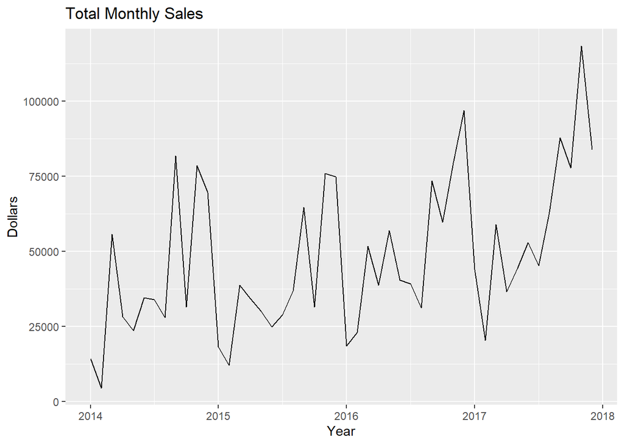

```r
forecast::autoplot(monthly_sales[,'total']) +
    ggtitle('Total Monthly Sales') +
    xlab('Year') +
    ylab('Dollars')  # Total Monthly Sales of company from 2014 to 2017
```

> We have seasonality and trend pattern

Total Monthly Sales and its Categories

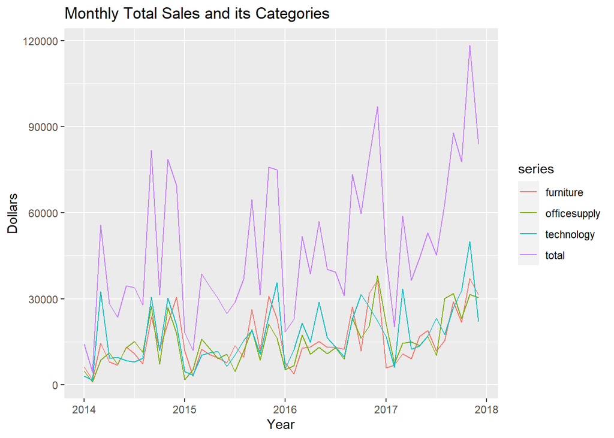

```r
autoplot(monthly_sales[,3:6]) +
    ggtitle('Monthly Total Sales and its Categories') +
    xlab('Year') +
    ylab('Dollars')
```

> result: it seems that the seasonality is very chromatic in this dataset

Seasonal Plot for Total Sales

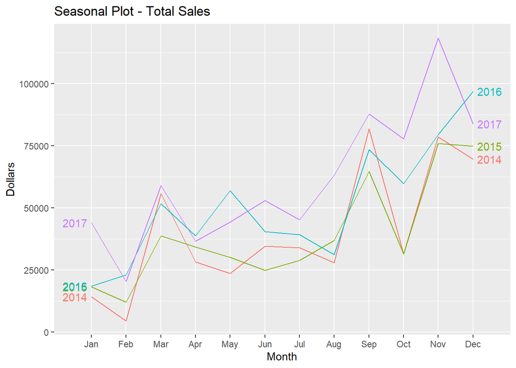

```r
forecast::ggseasonplot(monthly_sales[,'total'], year.labels = T, year.labels.left = T) +
    ylab('Dollars') +
    ggtitle('Seasonal Plot - Total Sales')  # line-chart plot: Timeseries of each year
```

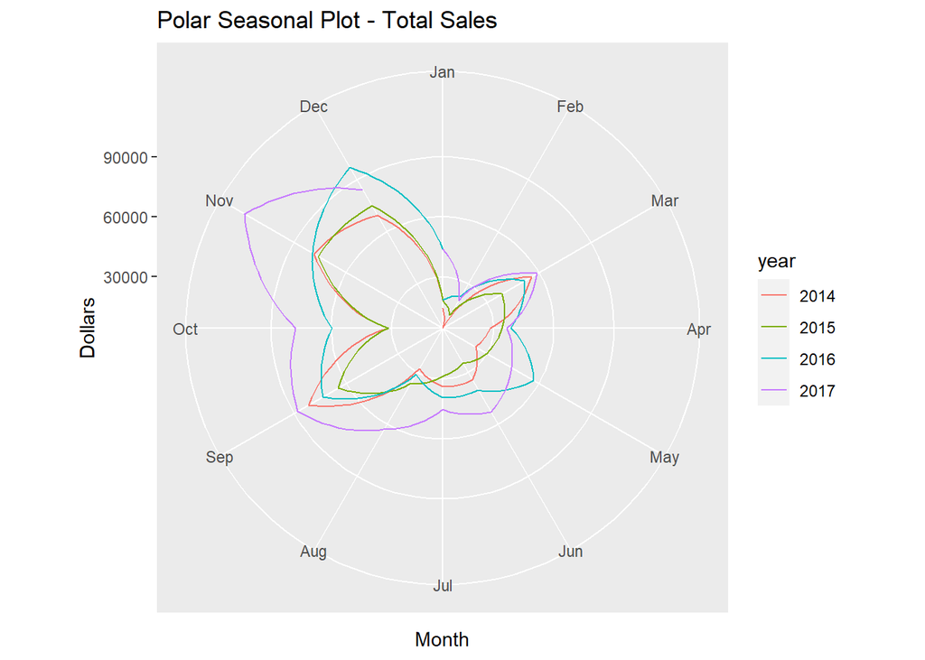

```r
forecast::ggseasonplot(monthly_sales[,'total'], polar = T) +
    ylab('Dollars') +
    ggtitle('Polar Seasonal Plot - Total Sales')  # Polar plot
```

> result: we see high seasonality patterns in this data by our eyes!

Seasonal Plot for Furniture Sales

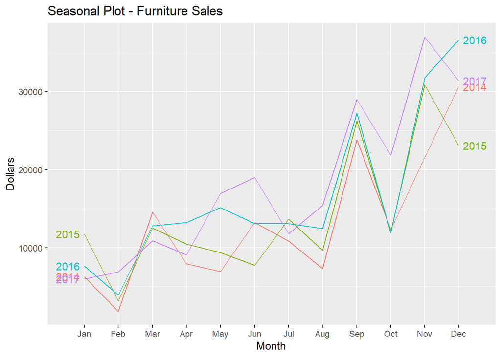

```r
ggseasonplot(monthly_sales[,'furniture'], year.labels = T, year.labels.left = T) +
    ylab('Dollars') +
    ggtitle('Seasonal Plot - Furniture Sales')
```

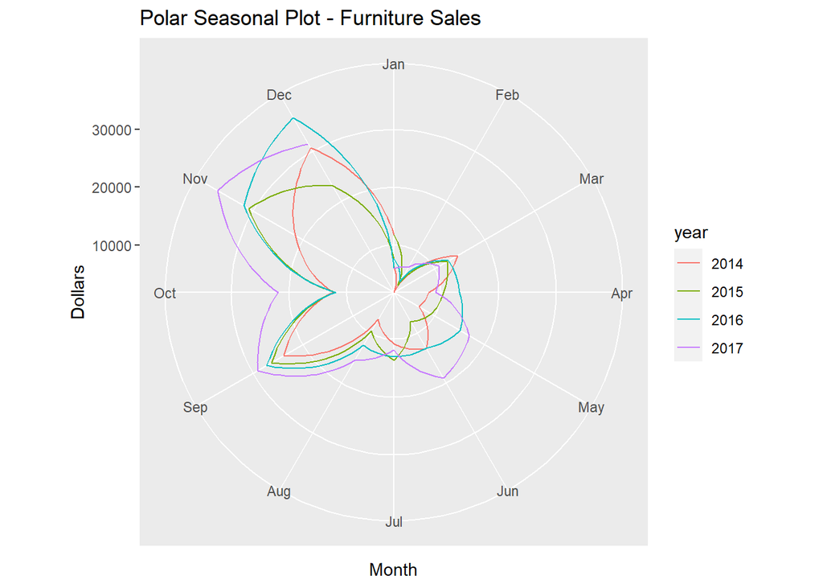

```r
ggseasonplot(monthly_sales[,'furniture'], polar = T) +
    ylab('Dollars') +
    ggtitle('Polar Seasonal Plot - Furniture Sales')  # Polar plot
```

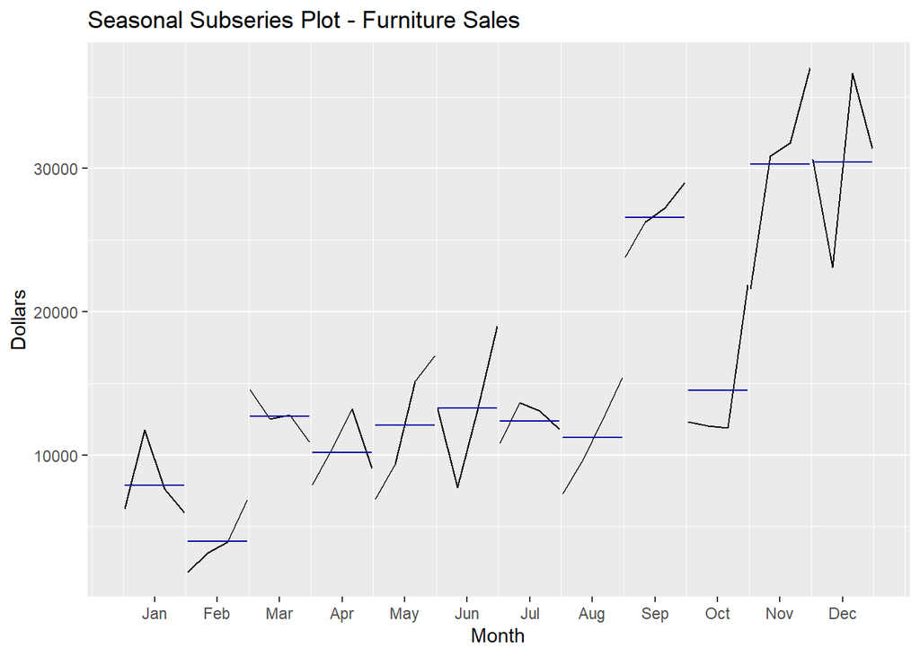

```r
ggsubseriesplot(monthly_sales[,'furniture']) +
    ylab('Dollars') +
    ggtitle('Seasonal Subseries Plot - Furniture Sales')
```

> min average is for Feb and max average is for Dec and Nov

Auto-correlation function

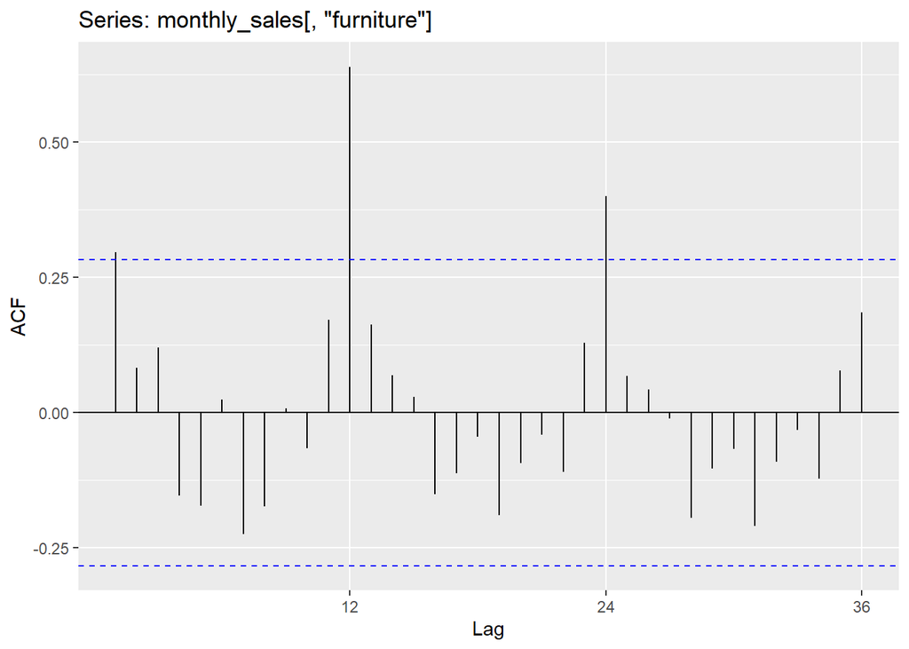

```r
ggAcf(monthly_sales[,'furniture'], lag.max = 36)
```

```r
2 / sqrt(nrow(monthly_sales))  # significant auto-correlation boundaries of chart
```

```
## [1] 0.2886751
```

- High significant auto-correlation with Lag_12 and Lag_24 -> this plot tells us we have seasonality in this dataset
- Lag_12 has the most auto-correlation with Yt
- Naive Prediction: if you want to predict current month’s Sales, consider the past year’s same month sales

Partial Auto-correlation

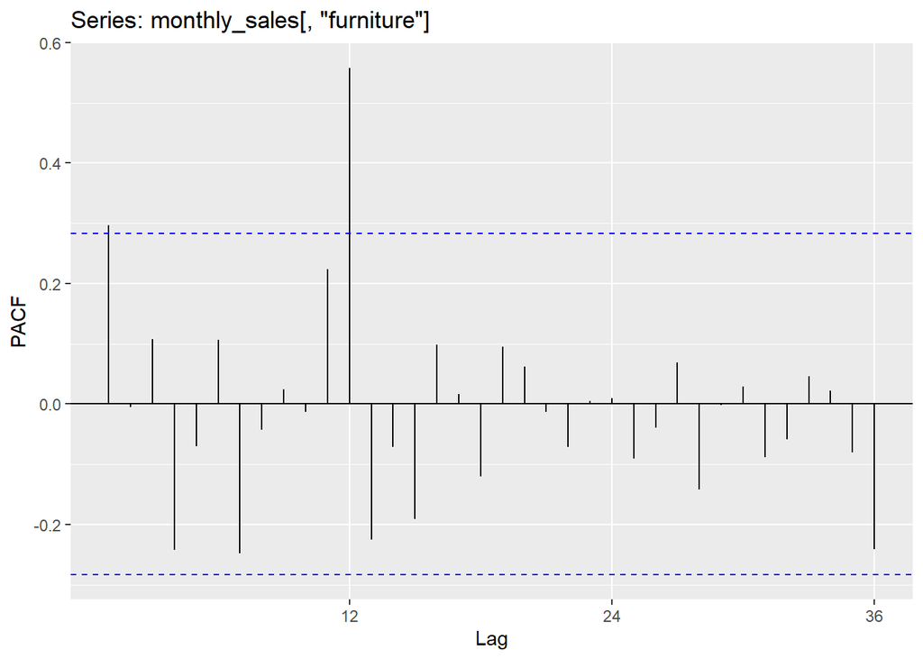

```r
ggPacf(monthly_sales[,'furniture'], lag.max = 36)
```

> Lag_12 has the most significant direct and pure effect on Yt

## 6.2 TimeSeries Decomposition

Extract Trend

```r
forecast::ma(monthly_sales[,'furniture'], 3, centre = T)  # calculate Moving Average
```

```
##            Jan       Feb       Mar       Apr       May       Jun       Jul
## 2014        NA  7552.046  8119.484  9810.527  9354.583 10313.321 10449.174
## 2015 15173.427  9124.700  8703.285 10783.477  9188.276 10254.516 10342.397
## 2016 11544.704  8116.462  9979.578 13711.006 13800.832 13752.975 12874.108
## 2017 16503.028  7907.938  8941.913 12305.654 15010.701 15926.389 15421.161
##            Aug       Sep       Oct       Nov       Dec
## 2014 13985.959 14480.358 19228.533 21505.029 21316.927
## 2015 16528.678 15979.413 23060.160 21997.758 20529.798
## 2016 17604.877 17206.230 23639.696 26778.307 24808.792
## 2017 18761.034 22118.049 29322.996 30116.083        NA
```

Plot Trend line

3-MA plot

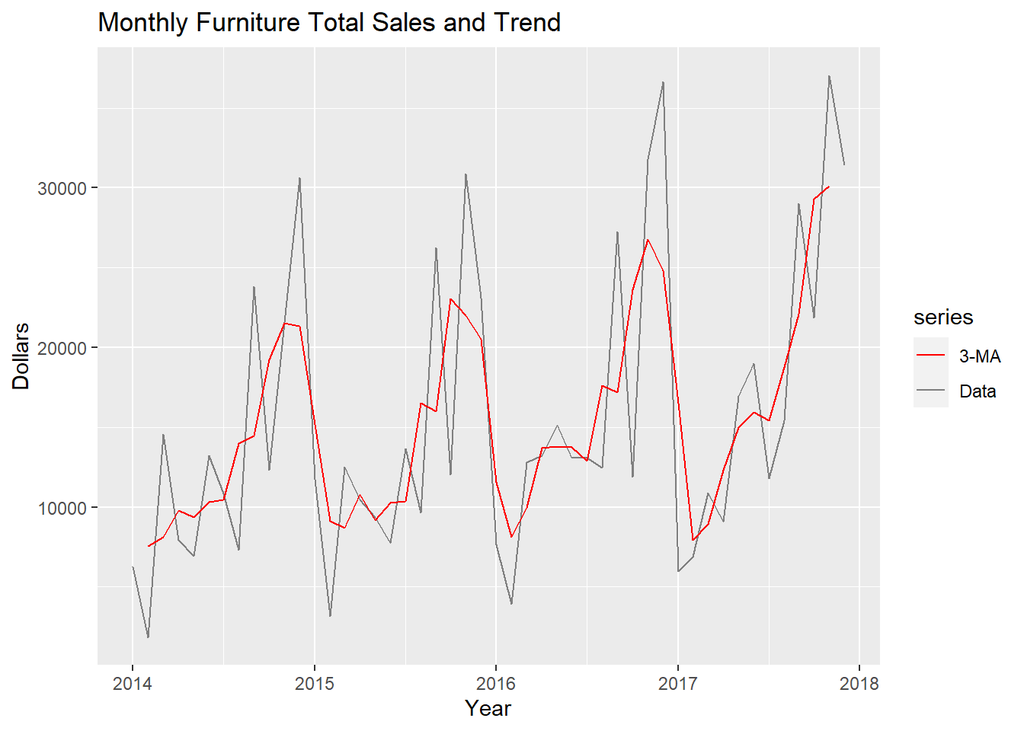

```r
autoplot(monthly_sales[,'furniture'], series = 'Data') +
    autolayer(ma(monthly_sales[,'furniture'], 3), series = '3-MA') +
    xlab('Year') + ylab('Dollars') +
    ggtitle('Monthly Furniture Total Sales and Trend') +
    scale_color_manual(values = c('Data' = 'grey50', '3-MA' = 'red'))
```

5-MA plot

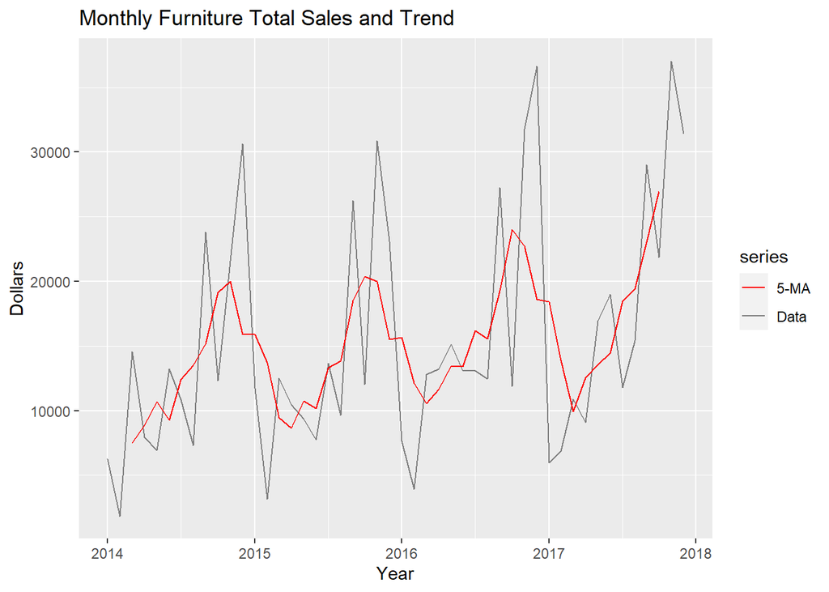

```r
autoplot(monthly_sales[,'furniture'], series = 'Data') +
    autolayer(ma(monthly_sales[,'furniture'], 5), series = '5-MA') +
    xlab('Year') + ylab('Dollars') +
    ggtitle('Monthly Furniture Total Sales and Trend') +
    scale_color_manual(values = c('Data' = 'grey50', '5-MA' = 'red'))
```

7-MA plot

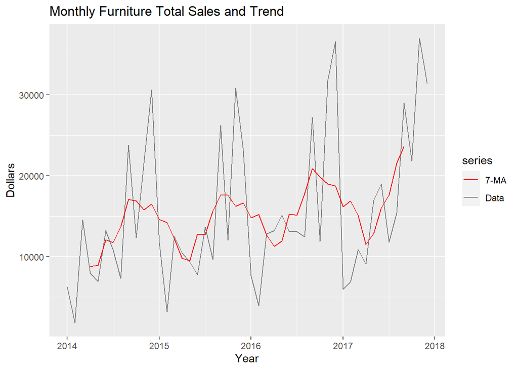

```r
autoplot(monthly_sales[,'furniture'], series = 'Data') +
    autolayer(ma(monthly_sales[,'furniture'], 7), series = '7-MA') +
    xlab('Year') + ylab('Dollars') +
    ggtitle('Monthly Furniture Total Sales and Trend') +
    scale_color_manual(values = c('Data' = 'grey50', '7-MA' = 'red'))
```

6-MA plot

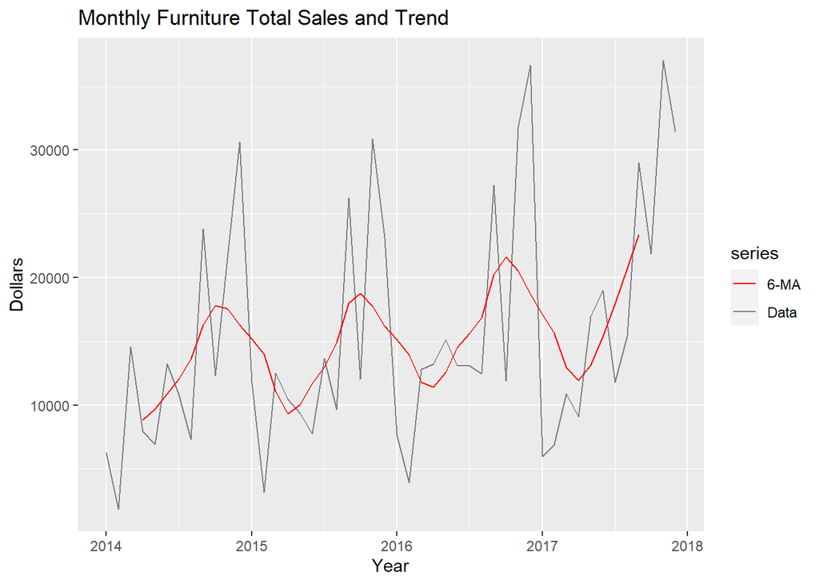

```r
autoplot(monthly_sales[,'furniture'], series = 'Data') +
    autolayer(ma(monthly_sales[,'furniture'], 6), series = '6-MA') +
    xlab('Year') + ylab('Dollars') +
    ggtitle('Monthly Furniture Total Sales and Trend') +
    scale_color_manual(values = c('Data' = 'grey50', '6-MA' = 'red'))
```

12-MA plot

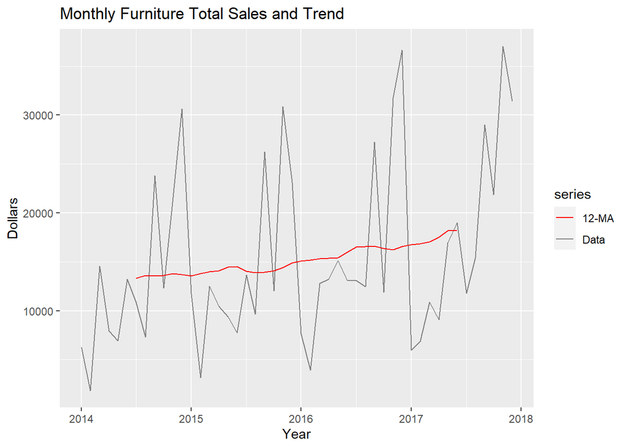

```r
autoplot(monthly_sales[,'furniture'], series = 'Data') +
    autolayer(ma(monthly_sales[,'furniture'], 12), series = '12-MA') +
    xlab('Year') + ylab('Dollars') +
    ggtitle('Monthly Furniture Total Sales and Trend') +
    scale_color_manual(values = c('Data' = 'grey50', '12-MA' = 'red'))  # pure Trend
```

> result: our data has Trend

### 6.2.1 Additive Decomposition approach

```r
ts_decomp_add <- decompose(monthly_sales[,'furniture'], type = 'additive')
ts_decomp_add$x  # input data
```

```
##            Jan       Feb       Mar       Apr       May       Jun       Jul
## 2014  6242.525  1839.658 14573.956  7944.837  6912.787 13206.126 10821.051
## 2015 11739.942  3134.374 12499.783 10475.699  9374.950  7714.179 13674.420
## 2016  7622.743  3925.551 12801.092 13212.090 15119.835 13070.572 13068.519
## 2017  5964.032  6866.337 10893.445  9065.958 16957.558 19008.587 11813.022
##            Aug       Sep       Oct       Nov       Dec
## 2014  7320.346 23816.481 12304.247 21564.873 30645.966
## 2015  9638.592 26273.023 12026.623 30880.833 23085.819
## 2016 12483.232 27262.881 11872.577 31783.629 36678.715
## 2017 15441.874 29028.206 21884.068 37056.715 31407.467
```

```r
ts_decomp_add$seasonal  # seasonal component
```

```
##             Jan        Feb        Mar        Apr        May        Jun
## 2014  -6634.523 -10561.251  -3323.749  -4676.045  -2124.730  -2903.473
## 2015  -6634.523 -10561.251  -3323.749  -4676.045  -2124.730  -2903.473
## 2016  -6634.523 -10561.251  -3323.749  -4676.045  -2124.730  -2903.473
## 2017  -6634.523 -10561.251  -3323.749  -4676.045  -2124.730  -2903.473
##             Jul        Aug        Sep        Oct        Nov        Dec
## 2014  -2036.786  -4810.006  11141.369  -2539.397  13314.150  15154.439
## 2015  -2036.786  -4810.006  11141.369  -2539.397  13314.150  15154.439
## 2016  -2036.786  -4810.006  11141.369  -2539.397  13314.150  15154.439
## 2017  -2036.786  -4810.006  11141.369  -2539.397  13314.150  15154.439
```

```r
ts_decomp_add$trend  # trend component (12-MA)
```

```
##           Jan      Feb      Mar      Apr      May      Jun      Jul      Aug
## 2014       NA       NA       NA       NA       NA       NA 13328.46 13611.47
## 2015 13569.88 13785.37 13984.31 14075.10 14451.70 14524.86 14038.30 13899.72
## 2016 15085.69 15178.97 15338.74 15373.56 15404.76 16008.75 16506.01 16559.43
## 2017 16773.14 16844.11 17040.94 17531.64 18168.50 18168.57       NA       NA
##           Sep      Oct      Nov      Dec
## 2014 13578.99 13598.02 13806.06 13679.82
## 2015 13945.24 14071.81 14425.20 14887.75
## 2016 16602.47 16350.23 16254.05 16578.04
## 2017       NA       NA       NA       NA
```

```r
ts_decomp_add$random  # remain component (random part)
```

```
##              Jan         Feb         Mar         Apr         May         Jun
## 2014          NA          NA          NA          NA          NA          NA
## 2015  4804.58321   -89.74057  1839.21720  1076.64030 -2952.01986 -3907.20735
## 2016  -828.42100  -692.16602   786.10249  2514.57089  1839.80317   -34.70413
## 2017 -4174.58856   583.48024 -2823.74604 -3789.63754   913.79035  3743.48513
##              Jul         Aug         Sep         Oct         Nov         Dec
## 2014  -470.62680 -1481.11679  -903.87957  1245.62326 -5555.34075  1811.70557
## 2015  1672.90251   548.87898  1186.41507   494.21003  3141.48554 -6956.36944
## 2016 -1400.70206   733.81147  -480.96185 -1938.25964  2215.42886  4946.23753
## 2017          NA          NA          NA          NA          NA          NA
```

```r
ts_decomp_add
```

```
## $x
##            Jan       Feb       Mar       Apr       May       Jun       Jul
## 2014  6242.525  1839.658 14573.956  7944.837  6912.787 13206.126 10821.051
## 2015 11739.942  3134.374 12499.783 10475.699  9374.950  7714.179 13674.420
## 2016  7622.743  3925.551 12801.092 13212.090 15119.835 13070.572 13068.519
## 2017  5964.032  6866.337 10893.445  9065.958 16957.558 19008.587 11813.022
##            Aug       Sep       Oct       Nov       Dec
## 2014  7320.346 23816.481 12304.247 21564.873 30645.966
## 2015  9638.592 26273.023 12026.623 30880.833 23085.819
## 2016 12483.232 27262.881 11872.577 31783.629 36678.715
## 2017 15441.874 29028.206 21884.068 37056.715 31407.467
##
## $seasonal
##             Jan        Feb        Mar        Apr        May        Jun
## 2014  -6634.523 -10561.251  -3323.749  -4676.045  -2124.730  -2903.473
## 2015  -6634.523 -10561.251  -3323.749  -4676.045  -2124.730  -2903.473
## 2016  -6634.523 -10561.251  -3323.749  -4676.045  -2124.730  -2903.473
## 2017  -6634.523 -10561.251  -3323.749  -4676.045  -2124.730  -2903.473
##             Jul        Aug        Sep        Oct        Nov        Dec
## 2014  -2036.786  -4810.006  11141.369  -2539.397  13314.150  15154.439
## 2015  -2036.786  -4810.006  11141.369  -2539.397  13314.150  15154.439
## 2016  -2036.786  -4810.006  11141.369  -2539.397  13314.150  15154.439
## 2017  -2036.786  -4810.006  11141.369  -2539.397  13314.150  15154.439
##
## $trend
##           Jan      Feb      Mar      Apr      May      Jun      Jul      Aug
## 2014       NA       NA       NA       NA       NA       NA 13328.46 13611.47
## 2015 13569.88 13785.37 13984.31 14075.10 14451.70 14524.86 14038.30 13899.72
## 2016 15085.69 15178.97 15338.74 15373.56 15404.76 16008.75 16506.01 16559.43
## 2017 16773.14 16844.11 17040.94 17531.64 18168.50 18168.57       NA       NA
##           Sep      Oct      Nov      Dec
## 2014 13578.99 13598.02 13806.06 13679.82
## 2015 13945.24 14071.81 14425.20 14887.75
## 2016 16602.47 16350.23 16254.05 16578.04
## 2017       NA       NA       NA       NA
##
## $random
##              Jan         Feb         Mar         Apr         May         Jun
## 2014          NA          NA          NA          NA          NA          NA
## 2015  4804.58321   -89.74057  1839.21720  1076.64030 -2952.01986 -3907.20735
## 2016  -828.42100  -692.16602   786.10249  2514.57089  1839.80317   -34.70413
## 2017 -4174.58856   583.48024 -2823.74604 -3789.63754   913.79035  3743.48513
##              Jul         Aug         Sep         Oct         Nov         Dec
## 2014  -470.62680 -1481.11679  -903.87957  1245.62326 -5555.34075  1811.70557
## 2015  1672.90251   548.87898  1186.41507   494.21003  3141.48554 -6956.36944
## 2016 -1400.70206   733.81147  -480.96185 -1938.25964  2215.42886  4946.23753
## 2017          NA          NA          NA          NA          NA          NA
##
## $figure
##  [1]  -6634.523 -10561.251  -3323.749  -4676.045  -2124.730  -2903.473
##  [7]  -2036.786  -4810.006  11141.369  -2539.397  13314.150  15154.439
##
## $type
## [1] "additive"
##
## attr(,"class")
## [1] "decomposed.ts"
```

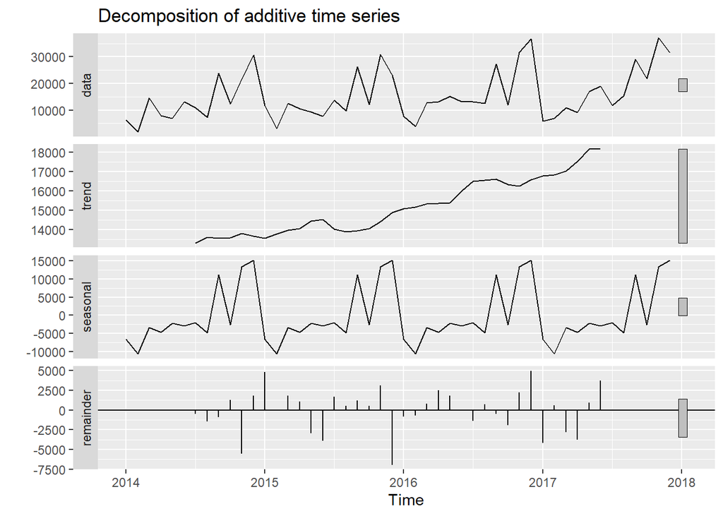

```r
autoplot(ts_decomp_add)  # plot decomposed components
```

> Trend is very weak and seasonality is very strong in this time-series.

### 6.2.2 Multiplicative Decomposition approach

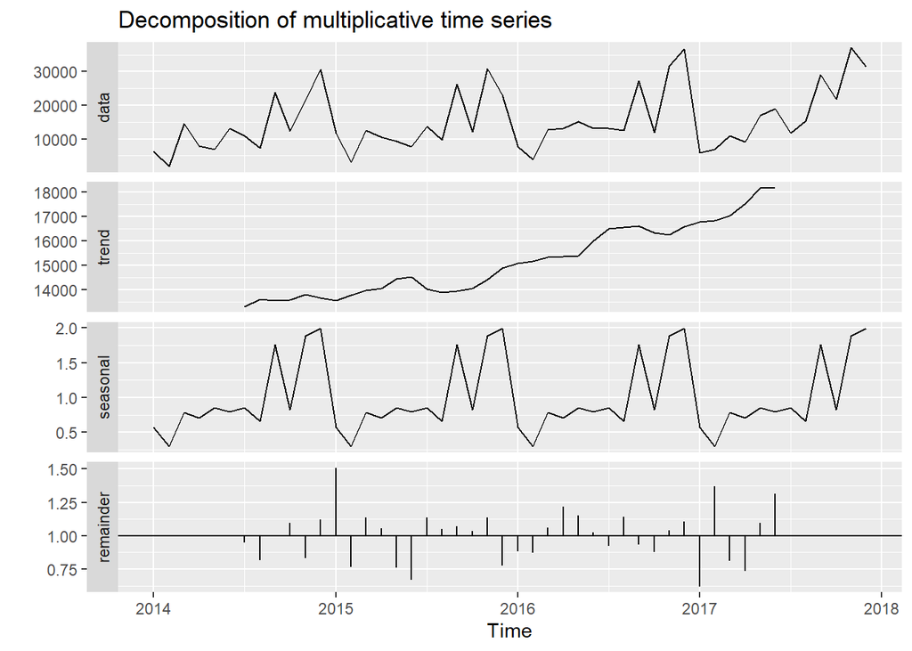

```r
ts_decomp_multi <- decompose(monthly_sales[,'furniture'], type = 'multiplicative')
autoplot(ts_decomp_multi)  # plot decomposed components
```

### 6.2.3 STL Decomposition approach

```r
ts_decomp_stl <- stl(monthly_sales[,'furniture'], t.window = 13, s.window = 'periodic')
ts_decomp_stl
```

```
##  Call:
##  stl(x = monthly_sales[, "furniture"], s.window = "periodic",
##     t.window = 13)
##
## Components
##            seasonal    trend   remainder
## Jan 2014  -7026.029 14108.62  -840.06920
## Feb 2014 -11157.348 13928.60  -931.59892
## Mar 2014  -2587.245 13748.59  3412.61473
## Apr 2014  -5166.199 13564.18  -453.14479
## May 2014  -3311.096 13379.78 -3155.89203
## Jun 2014  -2154.356 13123.29  2237.19022
## Jul 2014  -3061.805 12866.81  1016.04859
## Aug 2014  -4223.441 12878.99 -1335.20403
## Sep 2014  11112.303 12891.17  -186.99748
## Oct 2014  -1164.551 13238.67   230.13241
## Nov 2014  14431.503 13586.16 -6452.78637
## Dec 2014  14308.266 13903.97  2433.73239
## Jan 2015  -7026.029 14221.78  4544.19084
## Feb 2015 -11157.348 14354.63   -62.90787
## Mar 2015  -2587.245 14487.48   599.54840
## Apr 2015  -5166.199 14382.52  1259.38071
## May 2015  -3311.096 14277.55 -1591.50720
## Jun 2015  -2154.356 14125.15 -4256.61319
## Jul 2015  -3061.805 13972.74  2763.48265
## Aug 2015  -4223.441 13882.91   -20.87937
## Sep 2015  11112.303 13793.08  1367.63757
## Oct 2015  -1164.551 13911.37  -720.19943
## Nov 2015  14431.503 14029.67  2419.66388
## Dec 2015  14308.266 14332.66 -5555.10910
## Jan 2016  -7026.029 14635.66    13.11340
## Feb 2016 -11157.348 15064.43    18.46484
## Mar 2016  -2587.245 15493.21  -104.87234
## Apr 2016  -5166.199 15909.41  2468.88249
## May 2016  -3311.096 16325.60  2105.32759
## Jun 2016  -2154.356 16353.04 -1128.10978
## Jul 2016  -3061.805 16380.47  -250.14783
## Aug 2016  -4223.441 16415.24   291.42859
## Sep 2016  11112.303 16450.02  -299.43932
## Oct 2016  -1164.551 16438.54 -3401.41310
## Nov 2016  14431.503 16427.07   925.06065
## Dec 2016  14308.266 16432.09  5938.35833
## Jan 2017  -7026.029 16437.12 -3447.05481
## Feb 2017 -11157.348 16702.03  1321.65396
## Mar 2017  -2587.245 16966.95 -3486.25690
## Apr 2017  -5166.199 17116.76 -2884.60224
## May 2017  -3311.096 17266.57  3002.08249
## Jun 2017  -2154.356 17910.77  3252.17298
## Jul 2017  -3061.805 18554.97 -3680.14041
## Aug 2017  -4223.441 18997.89   667.42144
## Sep 2017  11112.303 19440.82 -1524.91635
## Oct 2017  -1164.551 19846.22  3202.40136
## Nov 2017  14431.503 20251.62  2373.59550
## Dec 2017  14308.266 20649.58 -3550.37441
```

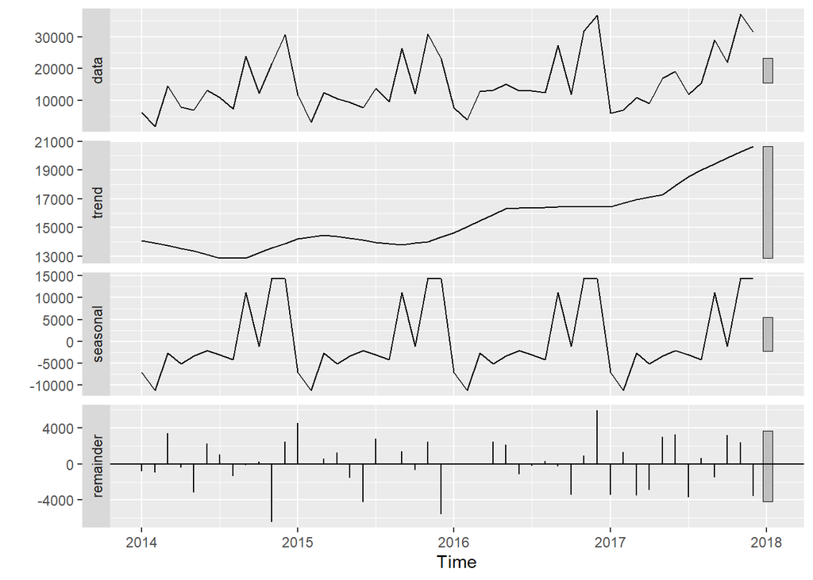

```r
autoplot(ts_decomp_stl)  # plot decomposed components
```

> Trend is very weak and seasonality is very strong in this time-series -> the most variance of this Timeseries is explained by Seasonality component

# 7 Modeling

```r
dim(monthly_sales)  # we have data for 48 months
```

```
## [1] 48  6
```

Train model on Jan 2014 to Dec 2016: from month 1 to 36

Test and evaluate model performance on Jan 2017 to Dec 2017: from month 37 to 48

## 7.1 Model 1: Average Method

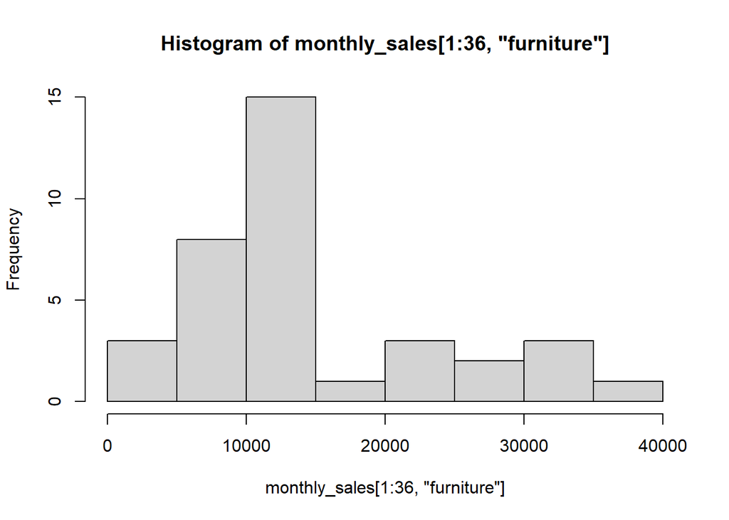

```r
hist(monthly_sales[1:36, 'furniture'])  # histogram of train data -> data is not from Normal distribution
```

With assumption that data is normally distributed

```r
meanf(monthly_sales[1:36, 'furniture'], 1)  # predict 1 next data
```

```
##   Point Forecast  Lo 80    Hi 80     Lo 95    Hi 95
## 1       14628.13 3061.2 26195.05 -3349.133 32605.38
```

- point estimate for next time-range (1 Jan 2017) is 14628.13
- confidence interval 80%: [3061.2 - 26195.05]
- confidence interval 95%: [-3349.133 - 32605.38]

Without assumption that data is normally distributed

```r
meanf(monthly_sales[1:36, 'furniture'], 1, bootstrap = T, npaths = 500, level = c(80, 95))
```

```
##   Point Forecast    Lo 80    Hi 80    Lo 95    Hi 95
## 1       14628.13 6242.525 30645.97 1839.658 36678.71
```

```r
meanf(monthly_sales[1:36, 'furniture'], 12)  # all of next 12 months will be same to next first month -> mean of data
```

```
##    Point Forecast  Lo 80    Hi 80     Lo 95    Hi 95
## 1        14628.13 3061.2 26195.05 -3349.133 32605.38
## 2        14628.13 3061.2 26195.05 -3349.133 32605.38
## 3        14628.13 3061.2 26195.05 -3349.133 32605.38
## 4        14628.13 3061.2 26195.05 -3349.133 32605.38
## 5        14628.13 3061.2 26195.05 -3349.133 32605.38
## 6        14628.13 3061.2 26195.05 -3349.133 32605.38
## 7        14628.13 3061.2 26195.05 -3349.133 32605.38
## 8        14628.13 3061.2 26195.05 -3349.133 32605.38
## 9        14628.13 3061.2 26195.05 -3349.133 32605.38
## 10       14628.13 3061.2 26195.05 -3349.133 32605.38
## 11       14628.13 3061.2 26195.05 -3349.133 32605.38
## 12       14628.13 3061.2 26195.05 -3349.133 32605.38
```

Expanding Window

```r
ave_method <- numeric(length = 12)  # vector to save prediction outputs
for(i in 1:12){
    ave_method[i] <- meanf(monthly_sales[1:(35+i), 'furniture'], 1)$mean  # extract point estimate column
}
ave_method
```

```
##  [1] 14628.13 14393.96 14195.87 14111.19 13985.06 14057.56 14175.44 14120.50
##  [9] 14150.53 14481.15 14642.08 15118.99
```

```r
ave_method <- ts(ave_method, start = 2017, frequency = 12)  # change vector to timeseries
ave_method
```

```
##           Jan      Feb      Mar      Apr      May      Jun      Jul      Aug
## 2017 14628.13 14393.96 14195.87 14111.19 13985.06 14057.56 14175.44 14120.50
##           Sep      Oct      Nov      Dec
## 2017 14150.53 14481.15 14642.08 15118.99
```

Errors

```r
err_ave_method <- (monthly_sales[37:48, 'furniture'] - ave_method)
methods_comp <- data.frame('Method' = 'AveMethod',
                'mean' = mean(abs(err_ave_method)),
                'median' = median(abs(err_ave_method)),
                'sd' = sd(abs(err_ave_method)),
                'IQR' = IQR(abs(err_ave_method)),
                'Min' = min(abs(err_ave_method)),
                'Max' = max(abs(err_ave_method)))
methods_comp
```

| Method | mean | median | sd | IQR | Min | Max |
| --- | --- | --- | --- | --- | --- | --- |
| AveMethod | 8094.201 | 6224.076 | 6511.902 | 6997.548 | 1321.375 | 22414.64 |

Plot Actual vs. Prediction

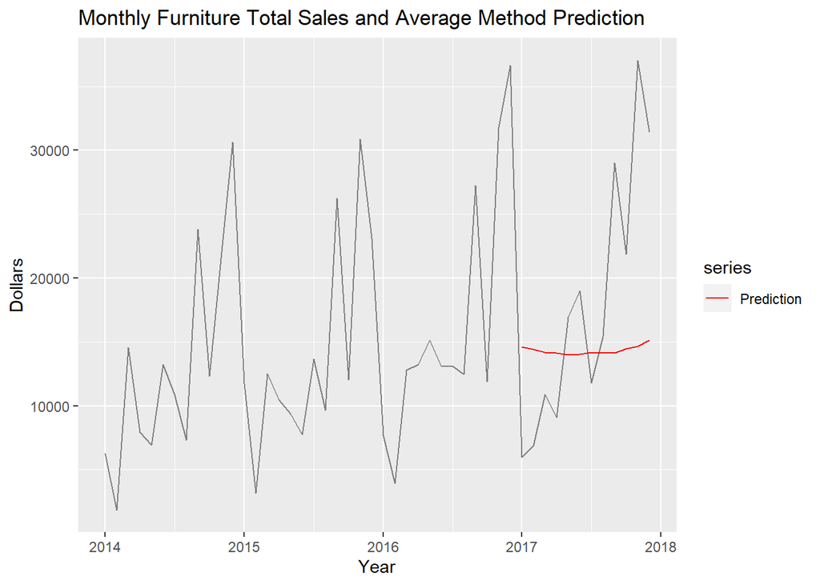

```r
autoplot(monthly_sales[, 'furniture'], series = 'Actual') +
    autolayer(ave_method, series = 'Prediction') +
    xlab('Year') + ylab('Dollars') +
    ggtitle('Monthly Furniture Total Sales and Average Method Prediction') +
    scale_colour_manual(values = c('Data' = 'grey50', 'Prediction' = 'red'))
```

> Idea: we can transform data to make it Normally-Distributed

## 7.2 Model 2: Average Method Adjusted Bias

```r
lambda <- forecast::BoxCox.lambda(monthly_sales[,'furniture'])  # gives us the optimum lambda
meanf(monthly_sales[1:36, 'furniture'], 1, lambda = lambda)
```

```
##   Point Forecast    Lo 80    Hi 80    Lo 95    Hi 95
## 1       12895.92 5025.664 27016.09 2598.404 38357.22
```

Expanding Window

```r
ave_method_adjbias <- numeric(length = 12)
for(i in 1:12){
    ave_method_adjbias[i] <- meanf(monthly_sales[1: (35 + i), 'furniture'], 1, lambda = lambda)$mean
}
ave_method_adjbias
```

```
##  [1] 12895.92 12656.63 12470.94 12428.58 12335.15 12435.75 12569.94 12551.96
##  [9] 12612.98 12879.20 13040.35 13381.85
```

```r
ave_method_adjbias <- ts(ave_method_adjbias, start = 2017, frequency = 12)
ave_method_adjbias
```

```
##           Jan      Feb      Mar      Apr      May      Jun      Jul      Aug
## 2017 12895.92 12656.63 12470.94 12428.58 12335.15 12435.75 12569.94 12551.96
##           Sep      Oct      Nov      Dec
## 2017 12612.98 12879.20 13040.35 13381.85
```

Errors

```r
err_ave_method_adjbias <- (monthly_sales[37:48, 'furniture'] - ave_method_adjbias)
methods_comp <- rbind(methods_comp, data.frame("Method" = "AveMethodAdjBias",
                                               "mean" = mean(abs(err_ave_method_adjbias)),
                                               "median" = median(abs(err_ave_method_adjbias)),
                                               "sd" = sd(abs(err_ave_method_adjbias)),
                                               "IQR" = IQR(abs(err_ave_method_adjbias)),
                                               "Min" = min(abs(err_ave_method_adjbias)),
                                               "Max" = max(abs(err_ave_method_adjbias))))
methods_comp
```

| Method | mean | median | sd | IQR | Min | Max |
| --- | --- | --- | --- | --- | --- | --- |
| AveMethod | 8094.201 | 6224.076 | 6511.902 | 6997.548 | 1321.3748 | 22414.64 |
| AveMethodAdjBias | 8330.537 | 6181.567 | 7313.433 | 7613.009 | 756.9188 | 24016.37 |

Plot Actual vs. Prediction

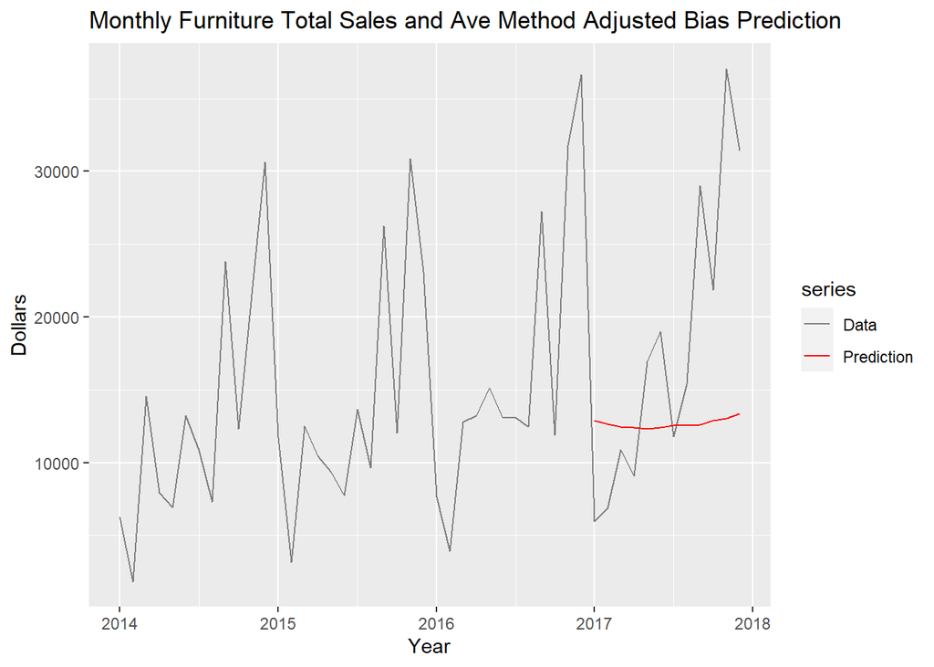

```r
autoplot(monthly_sales[, "furniture"], series = "Data") +
    autolayer(ave_method_adjbias, series = "Prediction") +
    xlab("Year") + ylab("Dollars") +
    ggtitle("Monthly Furniture Total Sales and Ave Method Adjusted Bias Prediction") +
    scale_colour_manual(values = c("Data" = "grey50", "Prediction" = "red"))
```

## 7.3 Model 3: Naive Method

```r
naive(monthly_sales[1:36, 'furniture'], 1)
```

```
##    Point Forecast    Lo 80    Hi 80    Lo 95    Hi 95
## 37       36678.71 23776.36 49581.07 16946.27 56411.16
```

> point-estimate for Jan 2017 is equals to Dec 2016 (it’s previous datapoint)

Expanding Window

```r
naive_method <- numeric(length = 12)
for(i in 1:12){
    naive_method[i] <- naive(monthly_sales[1: (35 + i), 'furniture'], 1)$mean
}
naive_method
```

```
##  [1] 36678.715  5964.032  6866.337 10893.445  9065.958 16957.558 19008.587
##  [8] 11813.022 15441.874 29028.206 21884.068 37056.715
```

```r
naive_method <- ts(naive_method, start = 2017, frequency = 12)
naive_method
```

```
##            Jan       Feb       Mar       Apr       May       Jun       Jul
## 2017 36678.715  5964.032  6866.337 10893.445  9065.958 16957.558 19008.587
##            Aug       Sep       Oct       Nov       Dec
## 2017 11813.022 15441.874 29028.206 21884.068 37056.715
```

Errors

```r
err_naive_method <- (monthly_sales[37:48, 'furniture'] - naive_method)
methods_comp <- rbind(methods_comp, data.frame("Method" = "NaiveMethod",
                                               "mean" = mean(abs(err_naive_method)),
                                               "median" = median(abs(err_naive_method)),
                                               "sd" = sd(abs(err_naive_method)),
                                               "IQR" = IQR(abs(err_naive_method)),
                                               "Min" = min(abs(err_naive_method)),
                                               "Max" = max(abs(err_naive_method))))
methods_comp
```

| Method | mean | median | sd | IQR | Min | Max |
| --- | --- | --- | --- | --- | --- | --- |
| AveMethod | 8094.201 | 6224.076 | 6511.902 | 6997.548 | 1321.3748 | 22414.64 |
| AveMethodAdjBias | 8330.537 | 6181.567 | 7313.433 | 7613.009 | 756.9188 | 24016.37 |
| NaiveMethod | 8315.916 | 6396.693 | 8328.968 | 6080.887 | 902.3054 | 30714.68 |

Plot Actual vs. Prediction

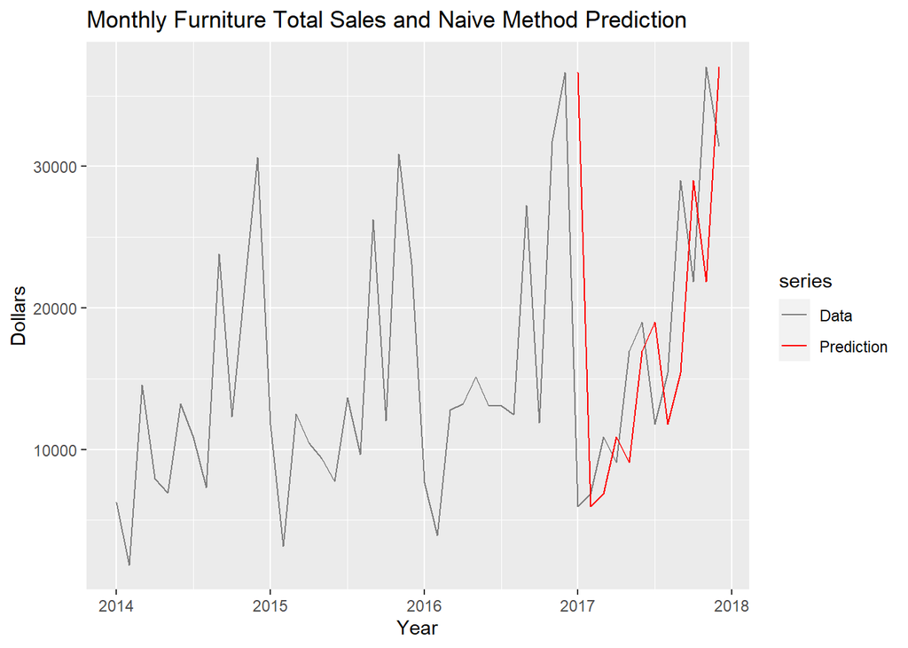

```r
autoplot(monthly_sales[, "furniture"], series = "Data") +
    autolayer(naive_method, series = "Prediction") +
    xlab("Year") + ylab("Dollars") +
    ggtitle("Monthly Furniture Total Sales and Naive Method Prediction") +
    scale_colour_manual(values = c("Data" = "grey50", "Prediction" = "red"))
```

## 7.4 Model 4: Simple Linear Regression

Split train data

```r
monthly_sales_train <- window(monthly_sales, start = 2014, end = c(2016, 12))  # cut data
monthly_sales_train
```

```
##          year month furniture officesupply technology     total
## Jan 2014 2014     1  6242.525     4851.080   3143.290 14236.895
## Feb 2014 2014     2  1839.658     1071.724   1608.510  4519.892
## Mar 2014 2014     3 14573.956     8605.879  32511.174 55691.009
## Apr 2014 2014     4  7944.837    11155.074   9195.434 28295.345
## May 2014 2014     5  6912.787     7135.624   9599.876 23648.287
## Jun 2014 2014     6 13206.126    12953.037   8435.965 34595.128
## Jul 2014 2014     7 10821.051    15121.208   8004.134 33946.393
## Aug 2014 2014     8  7320.346    11379.462   9209.660 27909.468
## Sep 2014 2014     9 23816.481    27423.298  30537.572 81777.351
## Oct 2014 2014    10 12304.247     7211.128  11938.018 31453.393
## Nov 2014 2014    11 21564.873    26862.436  30201.408 78628.717
## Dec 2014 2014    12 30645.966    18006.462  20893.192 69545.620
## Jan 2015 2015     1 11739.942     1808.780   4625.354 18174.076
## Feb 2015 2015     2  3134.374     5368.067   3448.970 11951.411
## Mar 2015 2015     3 12499.783    15882.547  10343.922 38726.252
## Apr 2015 2015     4 10475.699    12558.558  11160.952 34195.209
## May 2015 2015     5  9374.950     9113.736  11643.000 30131.686
## Jun 2015 2015     6  7714.179    10647.747   6435.366 24797.292
## Jul 2015 2015     7 13674.420     4719.939  10370.966 28765.325
## Aug 2015 2015     8  9638.592    11735.108  15524.632 36898.332
## Sep 2015 2015     9 26273.023    19305.767  19017.128 64595.918
## Oct 2015 2015    10 12026.623     8673.410  10704.890 31404.923
## Nov 2015 2015    11 30880.833    21218.130  23873.601 75972.564
## Dec 2015 2015    12 23085.819    16201.674  35632.028 74919.521
## Jan 2016 2016     1  7622.743     5299.682   5620.066 18542.491
## Feb 2016 2016     2  3925.551     6794.350  12258.914 22978.815
## Mar 2016 2016     3 12801.092    17346.931  21567.852 51715.875
## Apr 2016 2016     4 13212.090    10647.447  14890.502 38750.039
## May 2016 2016     5 15119.835    13035.202  28832.691 56987.728
## Jun 2016 2016     6 13070.572    10901.810  16372.152 40344.534
## Jul 2016 2016     7 13068.519    12924.444  13269.000 39261.963
## Aug 2016 2016     8 12483.232     8959.740   9672.402 31115.374
## Sep 2016 2016     9 27262.881    23263.738  22883.406 73410.025
## Oct 2016 2016    10 11872.577    16281.794  31533.374 59687.745
## Nov 2016 2016    11 31783.629    20487.278  27141.059 79411.966
## Dec 2016 2016    12 36678.715    37997.566  22322.762 96999.043
```

```r
reg_model <- tslm(monthly_sales_train[, 3] ~ trend + season)  # timeseries simple linear regression model based-on Trend and Seasonality components
reg_model
```

```
##
## Call:
## tslm(formula = monthly_sales_train[, 3] ~ trend + season)
##
## Coefficients:
## (Intercept)        trend      season2      season3      season4      season5
##      6652.4        144.8      -5713.4       4466.9       1574.7       1354.8
##     season6      season7      season8      season9     season10     season11
##      2071.1       3117.3        265.2      16090.5       2229.4      18093.2
##    season12
##     20008.7
```

```r
summary(reg_model)  # Adjusted R-squared = 0.8868
```

```
##
## Call:
## tslm(formula = monthly_sales_train[, 3] ~ trend + season)
##
## Residuals:
##     Min      1Q  Median      3Q     Max
## -7051.0  -919.7   -54.9  1357.1  4804.0
##
## Coefficients:
##             Estimate Std. Error t value Pr(>|t|)
## (Intercept)  6652.39    1816.96   3.661  0.00130 **
## trend         144.82      49.99   2.897  0.00813 **
## season2     -5713.36    2400.09  -2.380  0.02596 *
## season3      4466.90    2401.66   1.860  0.07573 .
## season4      1574.67    2404.26   0.655  0.51900
## season5      1354.84    2407.89   0.563  0.57911
## season6      2071.11    2412.56   0.858  0.39949
## season7      3117.33    2418.25   1.289  0.21018
## season8       265.24    2424.96   0.109  0.91385
## season9     16090.49    2432.67   6.614 9.51e-07 ***
## season10     2229.35    2441.39   0.913  0.37064
## season11    18093.16    2451.10   7.382 1.66e-07 ***
## season12    20008.73    2461.78   8.128 3.26e-08 ***
## ---
## Signif. codes:  0 '***' 0.001 '**' 0.01 '*' 0.05 '.' 0.1 ' ' 1
##
## Residual standard error: 2939 on 23 degrees of freedom
## Multiple R-squared:  0.9256, Adjusted R-squared:  0.8868
## F-statistic: 23.85 on 12 and 23 DF,  p-value: 3.853e-10
```

forecasting next 12-months Sales by this model

```r
reg_model_pred <- forecast(reg_model, h = 12)
reg_model_pred  # point-estimate with confidence intervals
```

```
##          Point Forecast     Lo 80    Hi 80     Lo 95    Hi 95
## Jan 2017      12010.785  7261.571 16760.00  4564.939 19456.63
## Feb 2017       6442.243  1693.029 11191.46 -1003.603 13888.09
## Mar 2017      16767.326 12018.111 21516.54  9321.479 24213.17
## Apr 2017      14019.924  9270.710 18769.14  6574.078 21465.77
## May 2017      13944.906  9195.692 18694.12  6499.060 21390.75
## Jun 2017      14806.007 10056.793 19555.22  7360.161 22251.85
## Jul 2017      15997.045 11247.831 20746.26  8551.199 23442.89
## Aug 2017      13289.772  8540.558 18038.99  5843.926 20735.62
## Sep 2017      29259.843 24510.629 34009.06 21813.997 36705.69
## Oct 2017      15543.531 10794.317 20292.75  8097.685 22989.38
## Nov 2017      31552.160 26802.946 36301.37 24106.314 38998.01
## Dec 2017      33612.549 28863.335 38361.76 26166.703 41058.39
```

```r
reg_model_pred$mean  # point-estimate column
```

```
##            Jan       Feb       Mar       Apr       May       Jun       Jul
## 2017 12010.785  6442.243 16767.326 14019.924 13944.906 14806.007 15997.045
##            Aug       Sep       Oct       Nov       Dec
## 2017 13289.772 29259.843 15543.531 31552.160 33612.549
```

Errors

```r
err_reg_method <- (monthly_sales[37:48, "furniture"] - reg_model_pred$mean)
methods_comp <- rbind(methods_comp, data.frame("Method" = "RegMethod",
                                               "mean" = mean(abs(err_reg_method)),
                                               "median" = median(abs(err_reg_method)),
                                               "sd" = sd(abs(err_reg_method)),
                                               "IQR" = IQR(abs(err_reg_method)),
                                               "Min" = min(abs(err_reg_method)),
                                               "Max" = max(abs(err_reg_method))))
methods_comp
```

| Method | mean | median | sd | IQR | Min | Max |
| --- | --- | --- | --- | --- | --- | --- |
| AveMethod | 8094.201 | 6224.076 | 6511.902 | 6997.548 | 1321.3748 | 22414.636 |
| AveMethodAdjBias | 8330.537 | 6181.567 | 7313.433 | 7613.009 | 756.9188 | 24016.368 |
| NaiveMethod | 8315.916 | 6396.693 | 8328.968 | 6080.887 | 902.3054 | 30714.683 |
| RegMethod | 3760.989 | 4193.301 | 2139.261 | 3405.050 | 231.6375 | 6340.537 |

Plot Actual vs. Prediction

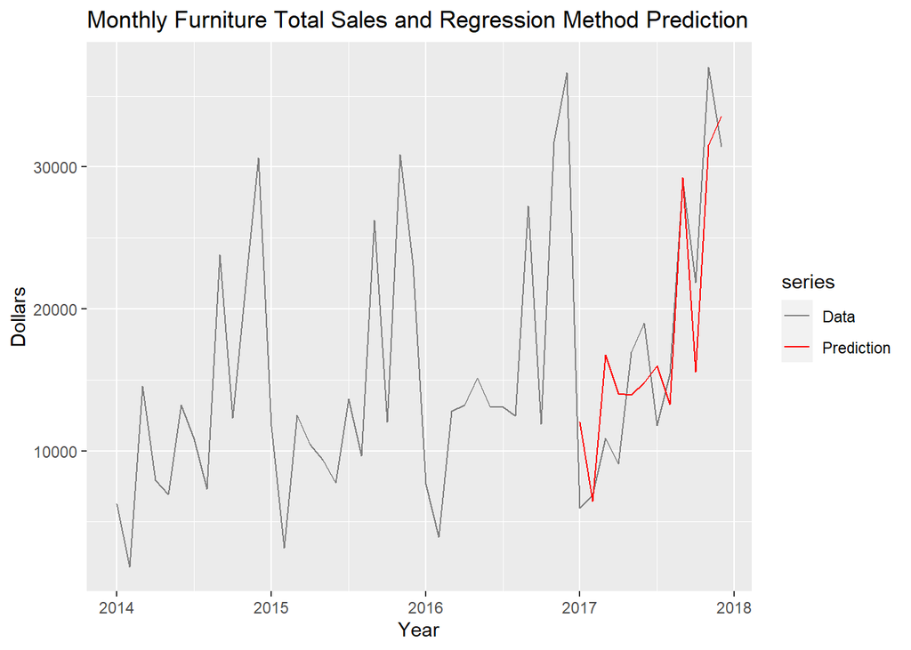

```r
autoplot(monthly_sales[, "furniture"], series = "Data") +
    autolayer(reg_model_pred$mean, series = "Prediction") +
    xlab("Year") + ylab("Dollars") +
    ggtitle("Monthly Furniture Total Sales and Regression Method Prediction") +
    scale_colour_manual(values = c("Data" = "grey50", "Prediction" = "red"))
```

## 7.5 Model 5: Exponential Smoothing approaches (Holt-Winters Method)

### 7.5.1 HW - Additive Model

```r
hw_model_1 <- ets(monthly_sales_train[, 3], model = 'AAA')
summary(hw_model_1)
```

```
## ETS(A,A,A)
##
## Call:
##  ets(y = monthly_sales_train[, 3], model = "AAA")
##
##   Smoothing parameters:
##     alpha = 1e-04
##     beta  = 1e-04
##     gamma = 1e-04
##
##   Initial states:
##     l = 12603.9178
##     b = 122.8238
##     s = 13645.54 12145.35 -1631.719 11320.57 -5238.124 -1397.803
##            -4639.098 -2643.154 -2842.637 -1972.874 -10914.23 -5831.814
##
##   sigma:  3425.71
##
##      AIC     AICc      BIC
## 727.8590 761.8590 754.7788
##
## Training set error measures:
##                     ME     RMSE     MAE       MPE     MAPE      MASE
## Training set -240.4062 2553.373 1965.27 -5.926199 15.17297 0.5733088
##                     ACF1
## Training set -0.08929995
```

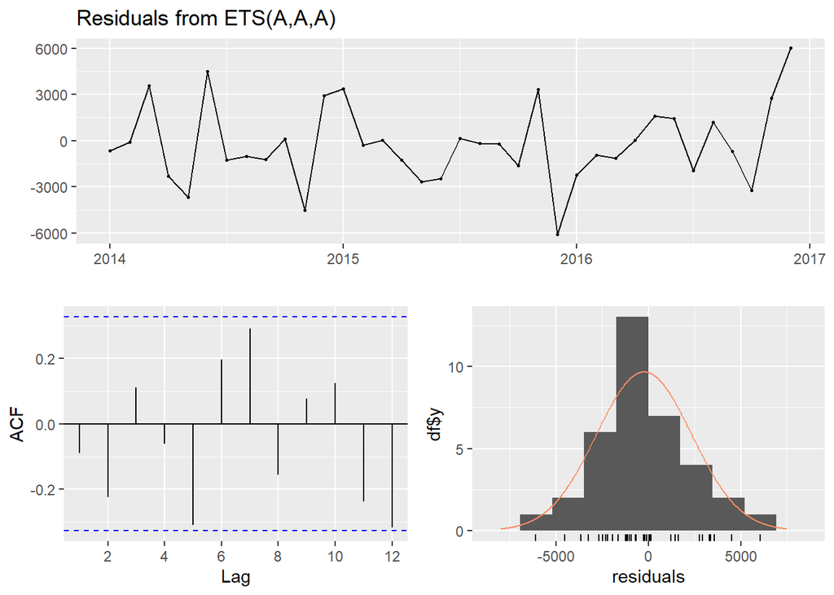

```
##
##  Ljung-Box test
##
## data:  Residuals from ETS(A,A,A)
## Q* = 12.995, df = 7, p-value = 0.07223
##
## Model df: 0.   Total lags used: 7
```

```r
checkresiduals(hw_model_1)  # plot training residuals -> to check how much it is similar to White-Noise (how much model is good?)
```

Ljung-Box test

H0: The data are independently distributed (the residuals are independent from each other) -> the Residuals have not any AutoCorrelation with each other

if p-value < 0.05 reject H0

### 7.5.2 HW - Multiplicative Model

```r
hw_model_2 <- ets(monthly_sales_train[,3], model = 'MAM')
summary(hw_model_2)
```

```
## ETS(M,A,M)
##
## Call:
##  ets(y = monthly_sales_train[, 3], model = "MAM")
##
##   Smoothing parameters:
##     alpha = 4e-04
##     beta  = 4e-04
##     gamma = 1e-04
##
##   Initial states:
##     l = 11925.3149
##     b = 142.3196
##     s = 1.9134 1.9136 0.8243 1.6933 0.642 0.8497
##            0.8255 0.7571 0.73 0.9892 0.2143 0.6475
##
##   sigma:  0.2249
##
##      AIC     AICc      BIC
## 713.5707 747.5707 740.4906
##
## Training set error measures:
##                     ME   RMSE      MAE       MPE     MAPE      MASE       ACF1
## Training set -83.51995 2325.3 1826.718 -4.238106 15.04919 0.5328903 -0.1132705
```

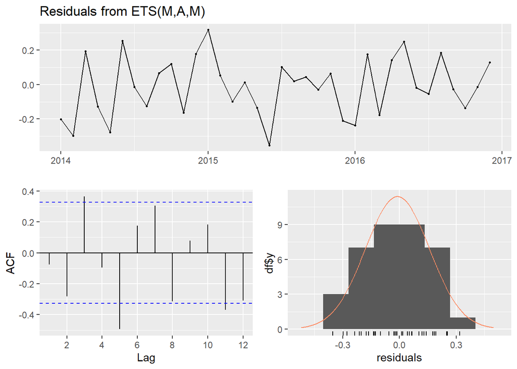

```
##
##  Ljung-Box test
##
## data:  Residuals from ETS(M,A,M)
## Q* = 25.883, df = 7, p-value = 0.0005286
##
## Model df: 0.   Total lags used: 7
```

```r
checkresiduals(hw_model_2)
```

Optimal Model (software proposal)

```r
hw_model_3 <- ets(monthly_sales_train[,3], model = 'ZZZ')
summary(hw_model_3)
```

```
## ETS(M,N,M)
##
## Call:
##  ets(y = monthly_sales_train[, 3], model = "ZZZ")
##
##   Smoothing parameters:
##     alpha = 0.0862
##     gamma = 2e-04
##
##   Initial states:
##     l = 14296.6432
##     s = 2.0833 1.8729 0.8289 1.7434 0.6867 0.8636
##            0.7403 0.7436 0.717 0.8691 0.2315 0.6196
##
##   sigma:  0.2615
##
##      AIC     AICc      BIC
## 721.2396 745.2396 744.9924
##
## Training set error measures:
##                    ME     RMSE      MAE       MPE     MAPE      MASE
## Training set 544.2253 2543.693 2051.543 -1.211415 17.11369 0.5984762
##                     ACF1
## Training set -0.07035195
```

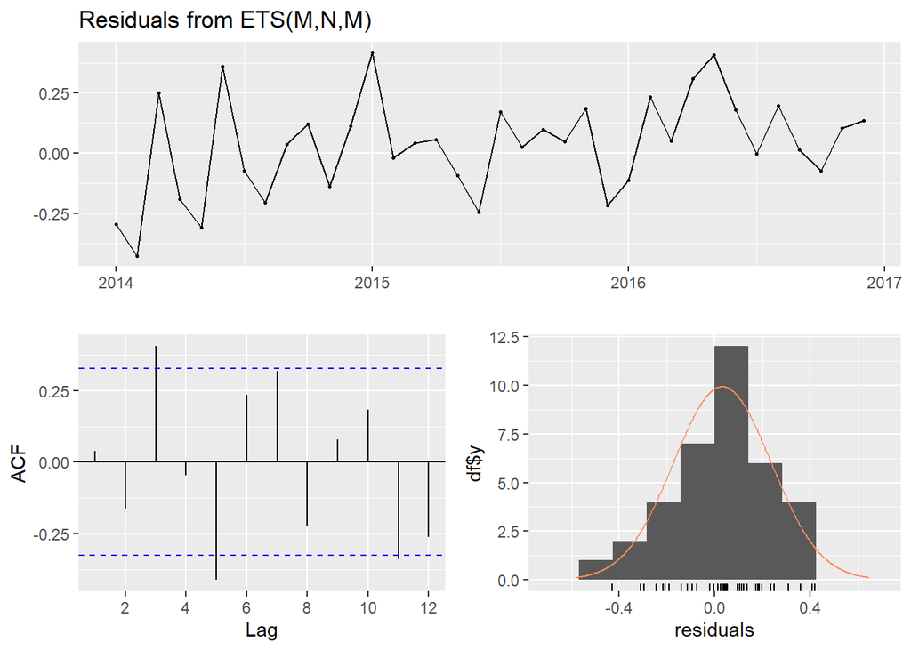

```
##
##  Ljung-Box test
##
## data:  Residuals from ETS(M,N,M)
## Q* = 22.744, df = 7, p-value = 0.001889
##
## Model df: 0.   Total lags used: 7
```

```r
checkresiduals(hw_model_3)
```

use Additive Model for prediction:

```r
hw_model_pred <- forecast(hw_model_1, h = 12)  # predict for next 12-months
hw_model_pred
```

```
##          Point Forecast     Lo 80    Hi 80      Lo 95    Hi 95
## Jan 2017      11289.079  6898.855 15679.30  4574.8108 18003.35
## Feb 2017       6328.363  1938.139 10718.59  -385.9051 13042.63
## Mar 2017      15392.003 11001.779 19782.23  8677.7343 22106.27
## Apr 2017      14643.512 10253.287 19033.74  7929.2424 21357.78
## May 2017      14964.763 10574.538 19354.99  8250.4928 21679.03
## Jun 2017      13091.556  8701.329 17481.78  6377.2839 19805.83
## Jul 2017      16454.070 12063.842 20844.30  9739.7958 23168.34
## Aug 2017      12735.952  8345.722 17126.18  6021.6754 19450.23
## Sep 2017      29416.313 25026.082 33806.54 22702.0339 36130.59
## Oct 2017      16585.645 12195.411 20975.88  9871.3613 23299.93
## Nov 2017      30485.254 26095.017 34875.49 23770.9659 37199.54
## Dec 2017      32107.477 27717.236 36497.72 25393.1830 38821.77
```

```r
hw_model_pred$mean  # point-estimate column
```

```
##            Jan       Feb       Mar       Apr       May       Jun       Jul
## 2017 11289.079  6328.363 15392.003 14643.512 14964.763 13091.556 16454.070
##            Aug       Sep       Oct       Nov       Dec
## 2017 12735.952 29416.313 16585.645 30485.254 32107.477
```

Errors

```r
err_hw_method <- (monthly_sales[37:48, "furniture"] - hw_model_pred$mean)
methods_comp <- rbind(methods_comp, data.frame("Method" = "HWMethod",
                                               "mean" = mean(abs(err_hw_method)),
                                               "median" = median(abs(err_hw_method)),
                                               "sd" = sd(abs(err_hw_method)),
                                               "IQR" = IQR(abs(err_hw_method)),
                                               "Min" = min(abs(err_hw_method)),
                                               "Max" = max(abs(err_hw_method))))
methods_comp
```

| Method | mean | median | sd | IQR | Min | Max |
| --- | --- | --- | --- | --- | --- | --- |
| AveMethod | 8094.201 | 6224.076 | 6511.902 | 6997.548 | 1321.3748 | 22414.636 |
| AveMethodAdjBias | 8330.537 | 6181.567 | 7313.433 | 7613.009 | 756.9188 | 24016.368 |
| NaiveMethod | 8315.916 | 6396.693 | 8328.968 | 6080.887 | 902.3054 | 30714.683 |
| RegMethod | 3760.989 | 4193.301 | 2139.261 | 3405.050 | 231.6375 | 6340.537 |
| HWMethod | 3679.494 | 4569.803 | 2281.734 | 3718.575 | 388.1074 | 6571.461 |

Plot Actual vs. Prediction

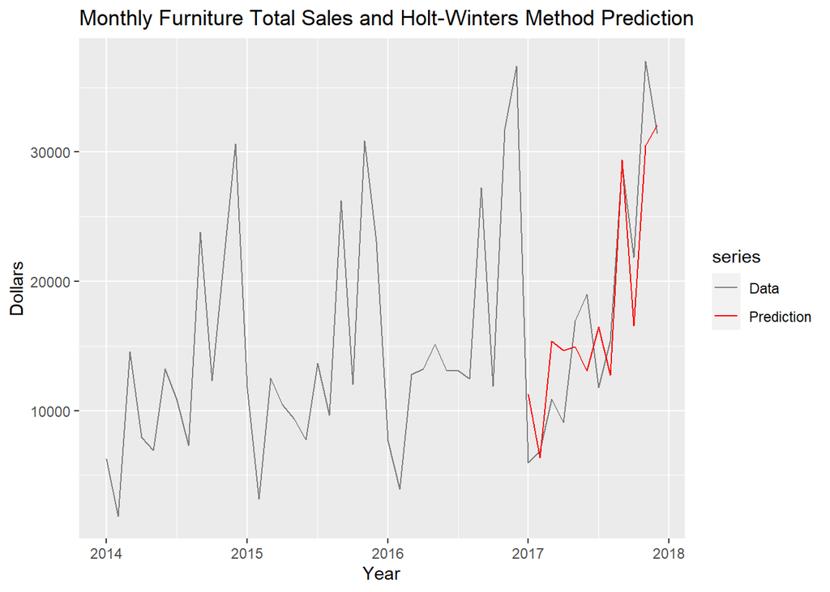

```r
autoplot(monthly_sales[, "furniture"], series = "Data") +
    autolayer(hw_model_pred$mean, series = "Prediction") +
    xlab("Year") + ylab("Dollars") +
    ggtitle("Monthly Furniture Total Sales and Holt-Winters Method Prediction") +
    scale_colour_manual(values = c("Data" = "grey50", "Prediction" = "red"))
```

## 7.6 Model 6: ARIMA Method

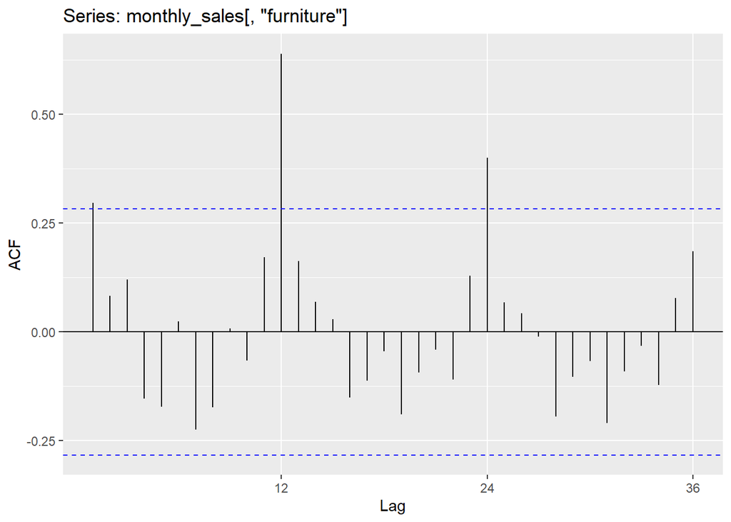

```r
ggAcf(monthly_sales[, 'furniture'], lag.max = 36)  # Auto-correlation
```

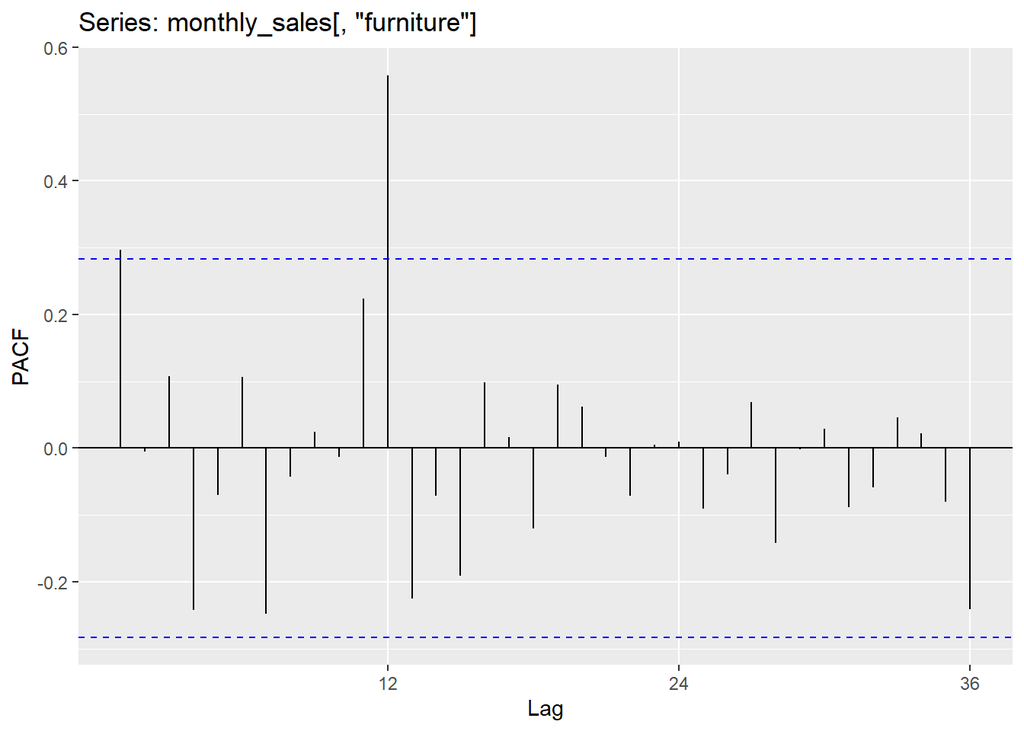

```r
ggPacf(monthly_sales[, 'furniture'], lag.max = 36)  # Partial-Auto-correlation
```

> Yt has high correlation with Lag-12 -> we have significant Seasonality in this Timeseries data

### 7.6.1 ARIMA(p,d,q) models without seasonality

#### 7.6.1.1 ARIMA(0, 1, 2)

```r
arima_model_1 <- arima(monthly_sales_train[,3], order = c(0, 1, 2))
arima_model_1
```

```
##
## Call:
## arima(x = monthly_sales_train[, 3], order = c(0, 1, 2))
##
## Coefficients:
##           ma1      ma2
##       -0.6506  -0.1280
## s.e.   0.1906   0.2307
##
## sigma^2 estimated as 73523464:  log likelihood = -367.07,  aic = 740.13
```

#### 7.6.1.2 ARIMA(1, 1, 0)

```r
arima_model_2 <- arima(monthly_sales_train[, 3], order = c(1, 1, 0))
arima_model_2
```

```
##
## Call:
## arima(x = monthly_sales_train[, 3], order = c(1, 1, 0))
##
## Coefficients:
##           ar1
##       -0.4369
## s.e.   0.1492
##
## sigma^2 estimated as 81156074:  log likelihood = -368.48,  aic = 740.95
```

#### 7.6.1.3 ARIMA(1, 1, 2)

```r
arima_model_3 <- arima(monthly_sales_train[, 3], order = c(1, 1, 2))
arima_model_3
```

```
##
## Call:
## arima(x = monthly_sales_train[, 3], order = c(1, 1, 2))
##
## Coefficients:
##          ar1      ma1     ma2
##       0.6213  -1.2579  0.3301
## s.e.  0.4588   0.4701  0.3883
##
## sigma^2 estimated as 72499257:  log likelihood = -366.82,  aic = 741.64
```

#### 7.6.1.4 ARIMA(p,d,q)(P,D,Q)[m] models with seasonality

```r
arima_model_4 <- auto.arima(monthly_sales_train[,3], seasonal = T)  # Optimal Model (software proposal)
arima_model_4
```

```
## Series: monthly_sales_train[, 3]
## ARIMA(0,0,0)(1,1,0)[12] with drift
##
## Coefficients:
##          sar1     drift
##       -0.6810  144.8194
## s.e.   0.1549   41.6863
##
## sigma^2 = 11013199:  log likelihood = -231.32
## AIC=468.65   AICc=469.85   BIC=472.18
```

Choose model with min(AIC)

```r
sarima_pred <- forecast(arima_model_4, h = 12)
sarima_pred$mean  # predictions
```

```
##            Jan       Feb       Mar       Apr       May       Jun       Jul
## 2017 13347.798  6308.047 15517.183 14269.912 14128.901 12344.197 16402.412
##            Aug       Sep       Oct       Nov       Dec
## 2017 13467.338 29510.077 14898.761 34090.113 30343.357
```

Errors

```r
err_sarima <- (monthly_sales[37:48, "furniture"] - sarima_pred$mean)
methods_comp <- rbind(methods_comp, data.frame("Method" = "SARIMA",
                                                 "mean" = mean(abs(err_sarima)),
                                                 "median" = median(abs(err_sarima)),
                                                 "sd" = sd(abs(err_sarima)),
                                                 "IQR" = IQR(abs(err_sarima)),
                                                 "Min" = min(abs(err_sarima)),
                                                 "Max" = max(abs(err_sarima))))
methods_comp
```

| Method | mean | median | sd | IQR | Min | Max |
| --- | --- | --- | --- | --- | --- | --- |
| AveMethod | 8094.201 | 6224.076 | 6511.902 | 6997.548 | 1321.3748 | 22414.636 |
| AveMethodAdjBias | 8330.537 | 6181.567 | 7313.433 | 7613.009 | 756.9188 | 24016.368 |
| NaiveMethod | 8315.916 | 6396.693 | 8328.968 | 6080.887 | 902.3054 | 30714.683 |
| RegMethod | 3760.989 | 4193.301 | 2139.261 | 3405.050 | 231.6375 | 6340.537 |
| HWMethod | 3679.494 | 4569.803 | 2281.734 | 3718.575 | 388.1074 | 6571.461 |
| SARIMA | 3777.051 | 3777.996 | 2494.264 | 3822.134 | 481.8708 | 7383.766 |

Plot Actual vs. Prediction

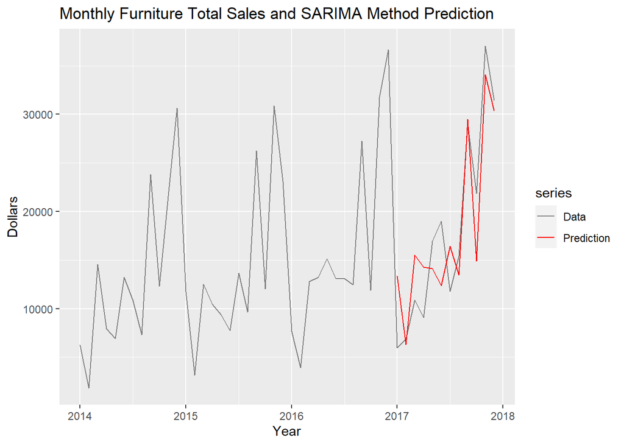

```r
autoplot(monthly_sales[, "furniture"], series = "Data") +
    autolayer(sarima_pred$mean, series = "Prediction") +
    xlab("Year") + ylab("Dollars") +
    ggtitle("Monthly Furniture Total Sales and SARIMA Method Prediction") +
    scale_colour_manual(values = c("Data" = "grey50", "Prediction" = "red"))
```

For more information check the [Github](https://github.com/mamomen1996/R_CS_11) repository.